# Homework4-5

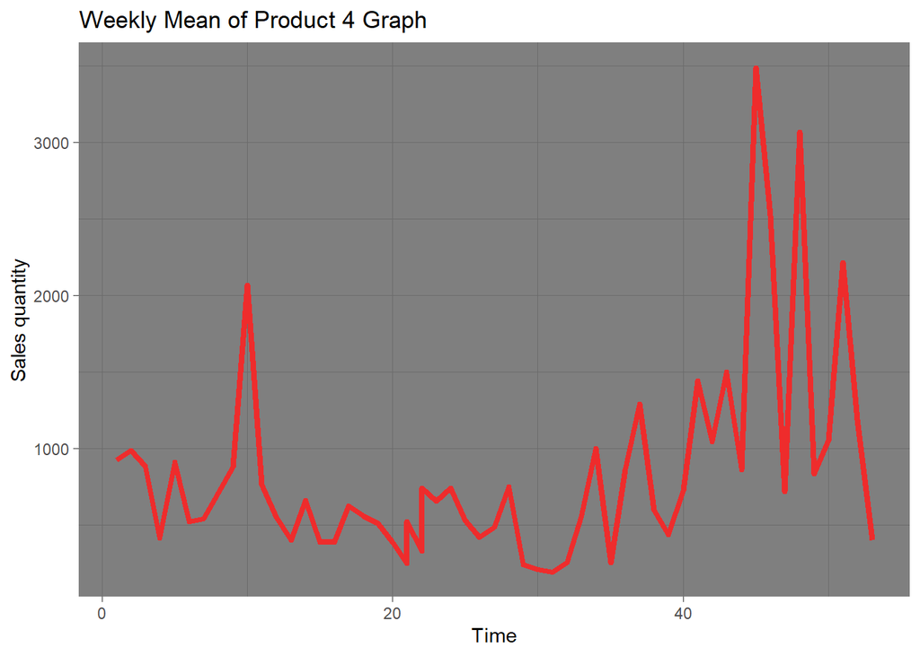

```r
ggplot(weekly_product4_data, aes(x = week, y = weekly_mean_sold_count)) +
    geom_line(colour = "firebrick2", size = 1.5) + labs(title = "Weekly Mean of Product 4 Graph",
    x = "Time", y = "Sales quantity") + theme_dark()
```

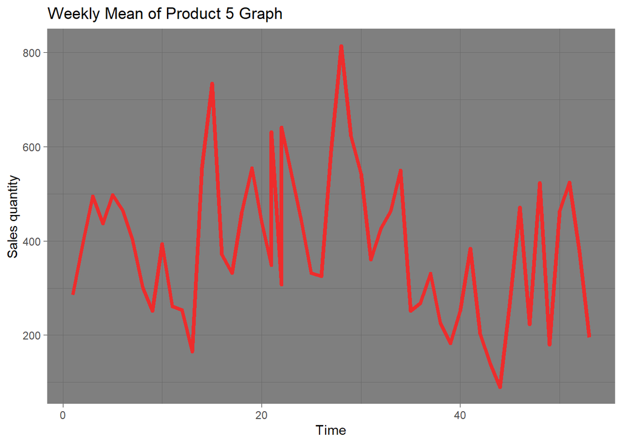

```r
ggplot(weekly_product5_data, aes(x = week, y = weekly_mean_sold_count)) +
    geom_line(colour = "firebrick2", size = 1.5) + labs(title = "Weekly Mean of Product 5 Graph",
    x = "Time", y = "Sales quantity") + theme_dark()
```

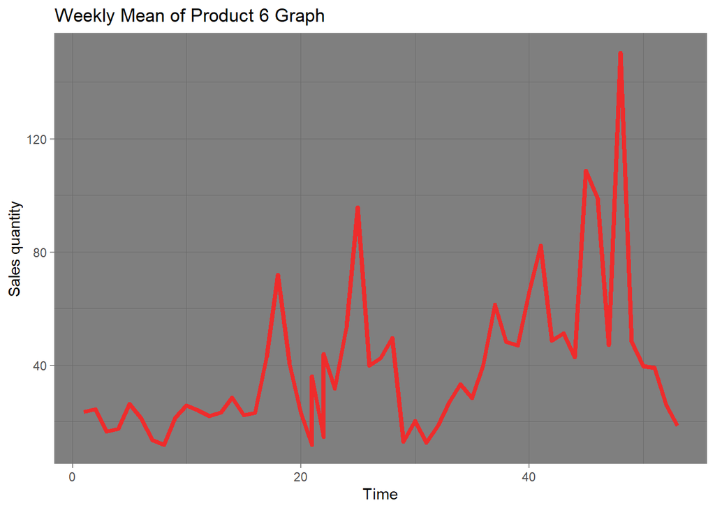

```r
ggplot(weekly_product6_data, aes(x = week, y = weekly_mean_sold_count)) +
    geom_line(colour = "firebrick2", size = 1.5) + labs(title = "Weekly Mean of Product 6 Graph",
    x = "Time", y = "Sales quantity") + theme_dark()
```

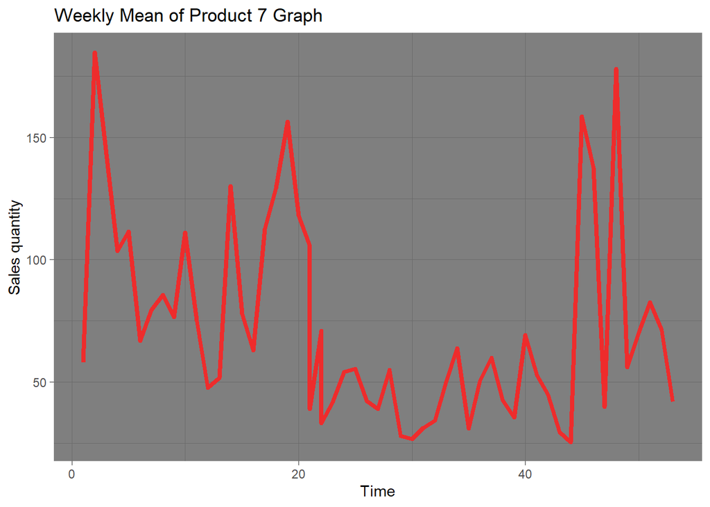

```r
ggplot(weekly_product7_data, aes(x = week, y = weekly_mean_sold_count)) +
    geom_line(colour = "firebrick2", size = 1.5) + labs(title = "Weekly Mean of Product 7 Graph",
    x = "Time", y = "Sales quantity") + theme_dark()
```

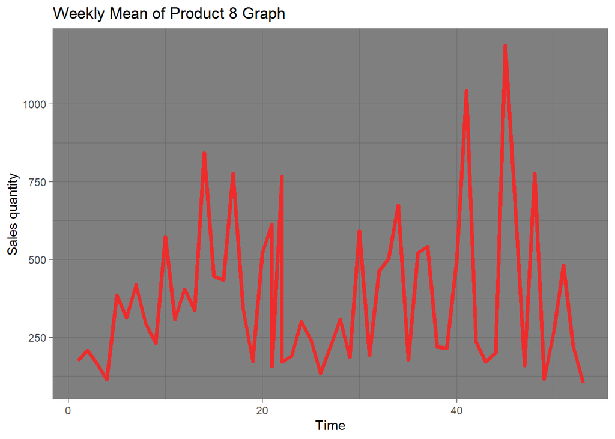

```r
ggplot(weekly_product8_data, aes(x = week, y = weekly_mean_sold_count)) +
    geom_line(colour = "firebrick2", size = 1.5) + labs(title = "Weekly Mean of Product 8 Graph",
    x = "Time", y = "Sales quantity") + theme_dark()
```

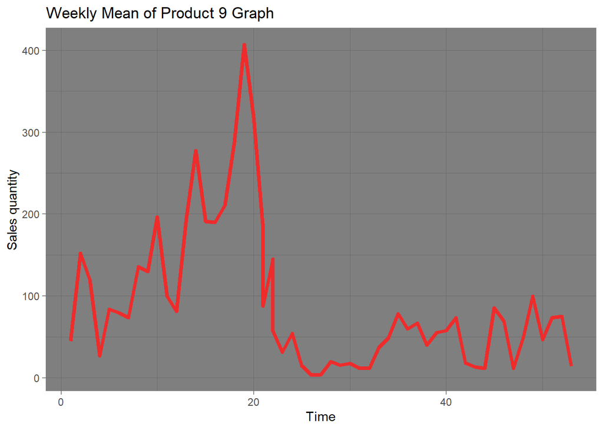

```r
ggplot(weekly_product9_data, aes(x = week, y = weekly_mean_sold_count)) +
    geom_line(colour = "firebrick2", size = 1.5) + labs(title = "Weekly Mean of Product 9 Graph",
    x = "Time", y = "Sales quantity") + theme_dark()
```

The aim is to purify the seasonality that is effect of factors such as price reductions and paydays that occur in the same periods of the months.

```r
weekly_product1_ts <- ts(weekly_product1_data$weekly_mean_sold_count,
    frequency = 4)
weekly_product2_ts <- ts(weekly_product2_data$weekly_mean_sold_count,
    frequency = 4)
weekly_product3_ts <- ts(weekly_product3_data$weekly_mean_sold_count,
    frequency = 4)
weekly_product4_ts <- ts(weekly_product4_data$weekly_mean_sold_count,
    frequency = 4)
weekly_product5_ts <- ts(weekly_product5_data$weekly_mean_sold_count,
    frequency = 4)
weekly_product6_ts <- ts(weekly_product6_data$weekly_mean_sold_count,
    frequency = 4)
weekly_product7_ts <- ts(weekly_product7_data$weekly_mean_sold_count,
    frequency = 4)
weekly_product8_ts <- ts(weekly_product8_data$weekly_mean_sold_count,
    frequency = 4)
weekly_product9_ts <- ts(weekly_product9_data$weekly_mean_sold_count,
    frequency = 4)

product1_dec_weekly <- decompose(x = weekly_product1_ts, type = "additive")
product2_dec_weekly <- decompose(x = weekly_product2_ts, type = "additive")
product3_dec_weekly <- decompose(x = weekly_product3_ts, type = "additive")
product4_dec_weekly <- decompose(x = weekly_product4_ts, type = "additive")
product5_dec_weekly <- decompose(x = weekly_product5_ts, type = "additive")
product6_dec_weekly <- decompose(x = weekly_product6_ts, type = "additive")
product7_dec_weekly <- decompose(x = weekly_product7_ts, type = "additive")
product8_dec_weekly <- decompose(x = weekly_product8_ts, type = "additive")
product9_dec_weekly <- decompose(x = weekly_product9_ts, type = "additive")
```

ACF plots of random components of products that are decomposed at weekly level:

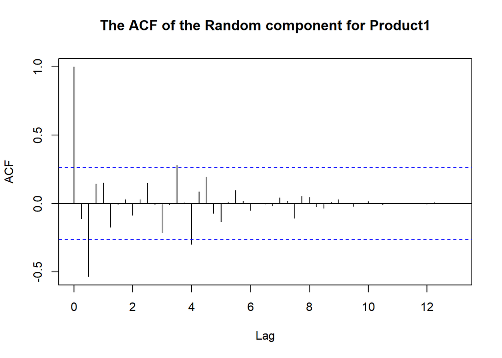

```r
acf(product1_dec_weekly$random, na.action = na.pass, lag.max = 52,
    main = "The ACF of the Random component for Product1")
```

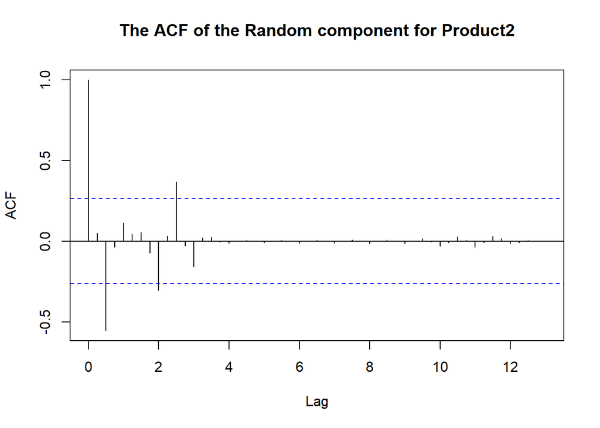

```r
acf(product2_dec_weekly$random, na.action = na.pass, lag.max = 52,
    main = "The ACF of the Random component for Product2")
```

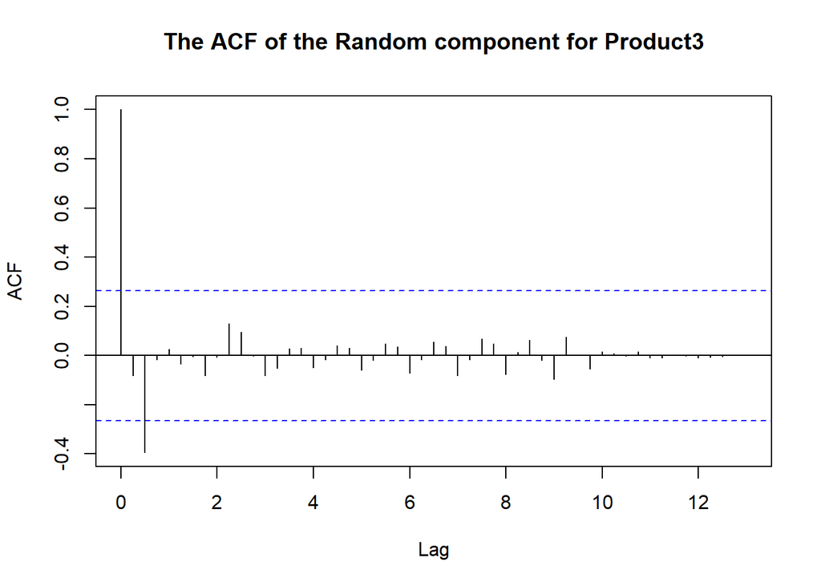

```r
acf(product3_dec_weekly$random, na.action = na.pass, lag.max = 52,
    main = "The ACF of the Random component for Product3")
```

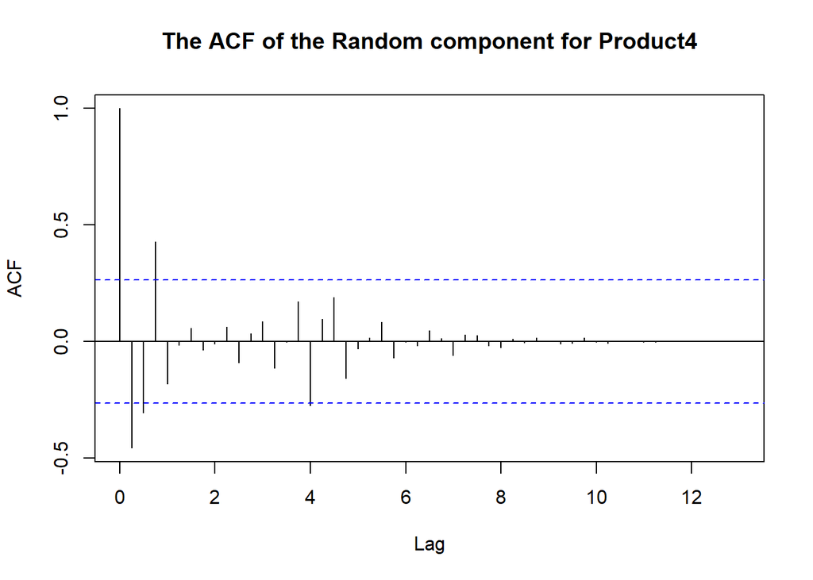

```r
acf(product4_dec_weekly$random, na.action = na.pass, lag.max = 52,
    main = "The ACF of the Random component for Product4")
```

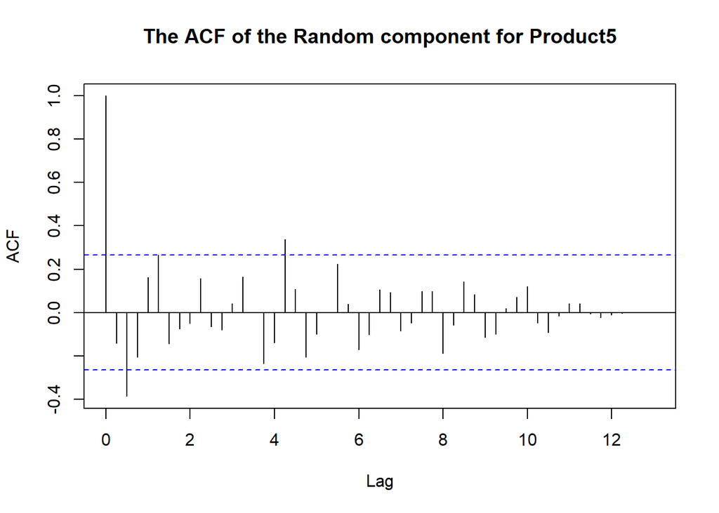

```r
acf(product5_dec_weekly$random, na.action = na.pass, lag.max = 52,
    main = "The ACF of the Random component for Product5")
```

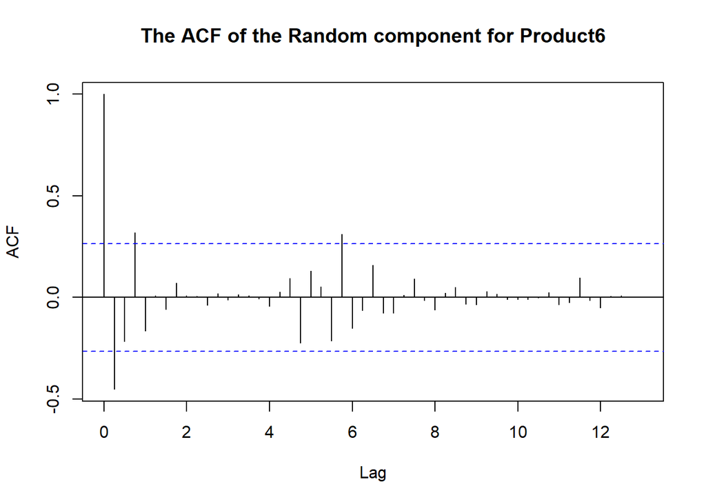

```r
acf(product6_dec_weekly$random, na.action = na.pass, lag.max = 52,
    main = "The ACF of the Random component for Product6")
```

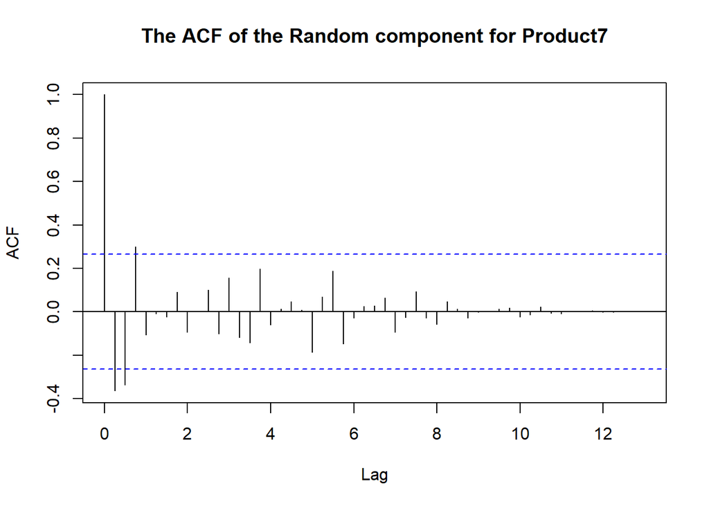

```r
acf(product7_dec_weekly$random, na.action = na.pass, lag.max = 52,
    main = "The ACF of the Random component for Product7")
```

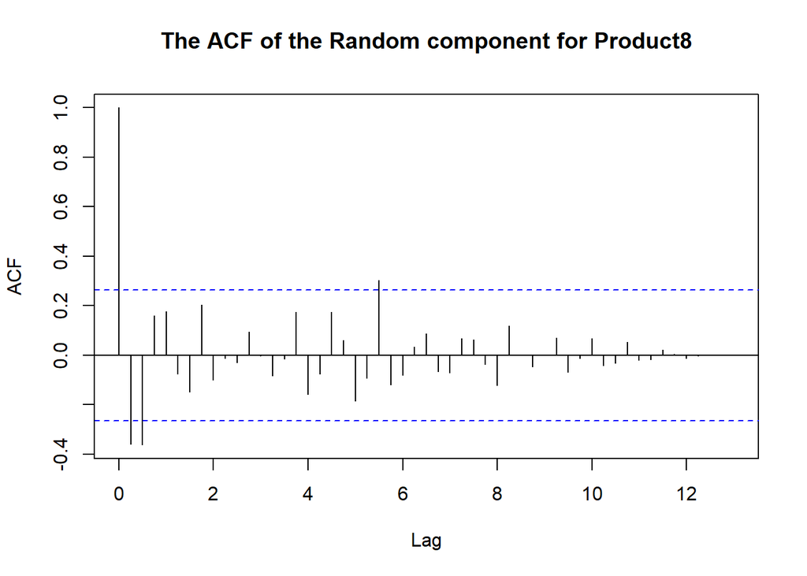

```r
acf(product8_dec_weekly$random, na.action = na.pass, lag.max = 52,
    main = "The ACF of the Random component for Product8")
```

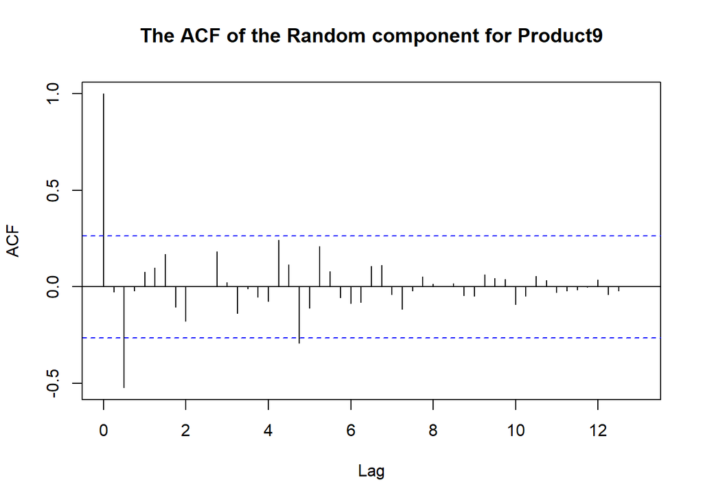

```r
acf(product9_dec_weekly$random, na.action = na.pass, lag.max = 52,
    main = "The ACF of the Random component for Product9")
```

There are still high autocorrelation values but they are generally purified from trend and seasonality.

```r
summary(ur.kpss(product1_dec_weekly$random))
```

```
##
## #######################
## # KPSS Unit Root Test #
## #######################
##
## Test is of type: mu with 3 lags.
##
## Value of test-statistic is: 0.0429
##
## Critical value for a significance level of:
##                 10pct  5pct 2.5pct  1pct
## critical values 0.347 0.463  0.574 0.739
```

```r
summary(ur.kpss(product2_dec_weekly$random))
```

```
##
## #######################
## # KPSS Unit Root Test #
## #######################
##
## Test is of type: mu with 3 lags.
##
## Value of test-statistic is: 0.0916
##
## Critical value for a significance level of:
##                 10pct  5pct 2.5pct  1pct
## critical values 0.347 0.463  0.574 0.739
```

```r
summary(ur.kpss(product3_dec_weekly$random))
```

```
##
## #######################
## # KPSS Unit Root Test #
## #######################
##
## Test is of type: mu with 3 lags.
##
## Value of test-statistic is: 0.086
##
## Critical value for a significance level of:
##                 10pct  5pct 2.5pct  1pct
## critical values 0.347 0.463  0.574 0.739
```

```r
summary(ur.kpss(product4_dec_weekly$random))
```

```
##
## #######################
## # KPSS Unit Root Test #
## #######################
##
## Test is of type: mu with 3 lags.
##
## Value of test-statistic is: 0.0362
##
## Critical value for a significance level of:
##                 10pct  5pct 2.5pct  1pct
## critical values 0.347 0.463  0.574 0.739
```

```r
summary(ur.kpss(product5_dec_weekly$random))
```

```
##
## #######################
## # KPSS Unit Root Test #
## #######################
##
## Test is of type: mu with 3 lags.
##
## Value of test-statistic is: 0.0738
##
## Critical value for a significance level of:
##                 10pct  5pct 2.5pct  1pct
## critical values 0.347 0.463  0.574 0.739
```

```r
summary(ur.kpss(product6_dec_weekly$random))
```

```
##
## #######################
## # KPSS Unit Root Test #
## #######################
##
## Test is of type: mu with 3 lags.
##
## Value of test-statistic is: 0.0366
##
## Critical value for a significance level of:
##                 10pct  5pct 2.5pct  1pct
## critical values 0.347 0.463  0.574 0.739
```

```r
summary(ur.kpss(product7_dec_weekly$random))
```

```
##
## #######################
## # KPSS Unit Root Test #
## #######################
##
## Test is of type: mu with 3 lags.
##
## Value of test-statistic is: 0.042
##
## Critical value for a significance level of:
##                 10pct  5pct 2.5pct  1pct
## critical values 0.347 0.463  0.574 0.739
```

```r
summary(ur.kpss(product8_dec_weekly$random))
```

```
##
## #######################
## # KPSS Unit Root Test #
## #######################
##
## Test is of type: mu with 3 lags.
##
## Value of test-statistic is: 0.0695
##
## Critical value for a significance level of:
##                 10pct  5pct 2.5pct  1pct
## critical values 0.347 0.463  0.574 0.739
```

```r
summary(ur.kpss(product9_dec_weekly$random))
```

```
##
## #######################
## # KPSS Unit Root Test #
## #######################
##
## Test is of type: mu with 3 lags.
##
## Value of test-statistic is: 0.1822
##
## Critical value for a significance level of:
##                 10pct  5pct 2.5pct  1pct
## critical values 0.347 0.463  0.574 0.739
```

The unit root tests suggest that the random components are stationary.However, the random components in the daily decomposition had lower values in the unit root test than those in the weekly decomposition.Therefore, we can say that the random components of the daily decomposition are more stationary.

We also set up the monthly decomposition model, but since the sales data of the products are 1 year, when we make them monthly_ts, they consist of only one observation and cannot be decomposed.

## ARIMA MODELS

we build arima models with random components of daily decomposition.

```r
product1_arima_model = auto.arima(product1_dec_daily$random,
    max.p = 2, max.q = 2)
product1_arima_model
```

```
## Series: product1_dec_daily$random
## ARIMA(0,0,1)(0,0,1)[7] with non-zero mean
##
## Coefficients:
##          ma1    sma1     mean
##       0.0890  0.2355  -0.0005
## s.e.  0.0284  0.0209   0.0710
##
## sigma^2 estimated as 7.236:  log likelihood=-6241.55
## AIC=12491.09   AICc=12491.11   BIC=12514.53
```

```r
product2_arima_model = auto.arima(product2_dec_daily$random,
    max.p = 2, max.q = 2)
product2_arima_model
```

```
## Series: product2_dec_daily$random
## ARIMA(2,0,0)(2,0,1)[7] with zero mean
##
## Coefficients:
##          ar1      ar2    sar1    sar2     sma1
##       0.3671  -0.4402  0.2061  0.1235  -0.1754
## s.e.  0.0189   0.0187  0.1113  0.0216   0.1122
##
## sigma^2 estimated as 123.6:  log likelihood=-9918.79
## AIC=19849.58   AICc=19849.61   BIC=19884.74
```

```r
product3_arima_model = auto.arima(product3_dec_daily$random,
    max.p = 2, max.q = 2)
product3_arima_model
```

```
## Series: product3_dec_daily$random
## ARIMA(2,0,0)(2,0,2)[7] with non-zero mean
##
## Coefficients:
##          ar1      ar2    sar1     sar2     sma1    sma2     mean
##       0.2245  -0.3637  1.1567  -0.8305  -1.1510  0.7316  -0.0056
## s.e.  0.0195   0.0196  0.0789   0.0421   0.1016  0.0647   0.0765
##
## sigma^2 estimated as 26.56:  log likelihood=-7925.22
## AIC=15866.43   AICc=15866.49   BIC=15913.31
```

```r
product4_arima_model = auto.arima(product4_dec_daily$random,
    max.p = 2, max.q = 2)
product4_arima_model
```

```
## Series: product4_dec_daily$random
## ARIMA(1,0,2)(0,0,1)[7] with zero mean
##
## Coefficients:
##           ar1     ma1     ma2    sma1
##       -0.1484  0.5623  0.1678  0.1263
## s.e.   0.0900  0.0866  0.0332  0.0201
##
## sigma^2 estimated as 315640:  log likelihood=-20086.45
## AIC=40182.9   AICc=40182.92   BIC=40212.2
```

```r
product5_arima_model = auto.arima(product5_dec_daily$random,
    max.p = 2, max.q = 2)
product5_arima_model
```

```
## Series: product5_dec_daily$random
## ARIMA(1,0,1)(1,0,1)[7] with zero mean
##
## Coefficients:
##           ar1     ma1     sar1    sma1
##       -0.0229  0.2056  -0.1856  0.2837
## s.e.   0.0530  0.0491   0.1669  0.1632
##
## sigma^2 estimated as 15049:  log likelihood=-16142.25
## AIC=32294.49   AICc=32294.52   BIC=32323.79
```

```r
product6_arima_model = auto.arima(product6_dec_daily$random,
    max.p = 2, max.q = 2)
product6_arima_model
```

```
## Series: product6_dec_daily$random
## ARIMA(1,0,2)(1,0,1)[7] with zero mean
##
## Coefficients:
##           ar1     ma1     ma2     sar1    sma1
##       -0.2801  0.5579  0.3024  -0.5928  0.6915
## s.e.   0.0598  0.0547  0.0217   0.0719  0.0643
##
## sigma^2 estimated as 388.7:  log likelihood=-11403.31
## AIC=22818.62   AICc=22818.65   BIC=22853.78
```

```r
product7_arima_model = auto.arima(product7_dec_daily$random,
    max.p = 2, max.q = 2)
product7_arima_model
```

```
## Series: product7_dec_daily$random
## ARIMA(1,0,2)(2,0,1)[7] with zero mean
##
## Coefficients:
##           ar1     ma1     ma2     sar1     sar2    sma1
##       -0.5086  0.8848  0.3308  -0.4717  -0.0636  0.5021
## s.e.   0.1020  0.0937  0.0239   0.1614   0.0238  0.1614
##
## sigma^2 estimated as 1046:  log likelihood=-12685.84
## AIC=25385.69   AICc=25385.73   BIC=25426.71
```

```r
product8_arima_model = auto.arima(product8_dec_daily$random,
    max.p = 2, max.q = 2)
product8_arima_model
```

```
## Series: product8_dec_daily$random
## ARIMA(0,0,1)(0,0,1)[7] with zero mean
##
## Coefficients:
##          ma1    sma1
##       0.2999  0.0483
## s.e.  0.0173  0.0193
##
## sigma^2 estimated as 67920:  log likelihood=-18096.36
## AIC=36198.71   AICc=36198.72   BIC=36216.29
```

```r
product9_arima_model = auto.arima(product9_dec_daily$random,
    max.p = 2, max.q = 2)
product9_arima_model
```

```
## Series: product9_dec_daily$random
## ARIMA(1,0,1)(1,0,1)[7] with zero mean
##
## Coefficients:
##           ar1     ma1     sar1    sma1
##       -0.0651  0.4105  -0.0801  0.2063
## s.e.   0.0385  0.0325   0.1519  0.1494
##
## sigma^2 estimated as 1137:  log likelihood=-12795.32
## AIC=25600.64   AICc=25600.66   BIC=25629.94
```

### Question 3 starts here

In this part, we will be trying to investigate the possible regressors that are likely to increase the quality of our arima models for each product. Some manipulations are made in order to get rid of the missing values in the product datas.

##Product1 ARIMAX

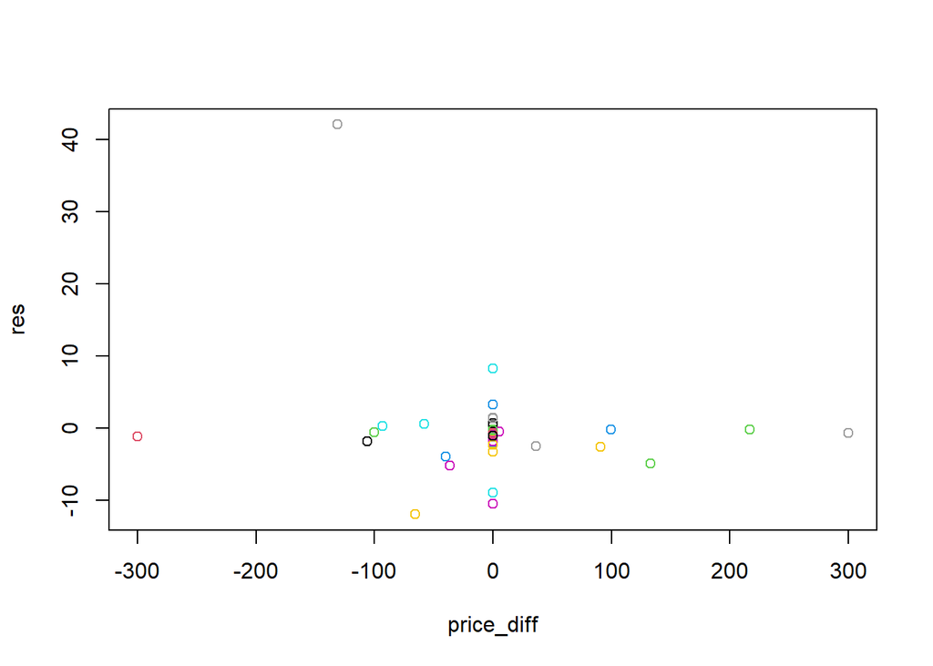

```r
product1_data[, `:=`(price_diff, price - shift(price, 1))]

product1_data[, `:=`(res, c(rep(NA, 7), as.numeric(product1_arima_model$residuals[1:365])))]

plot(product1_data[, list(price_diff, res)], col = day(product1_data$event_date))
```

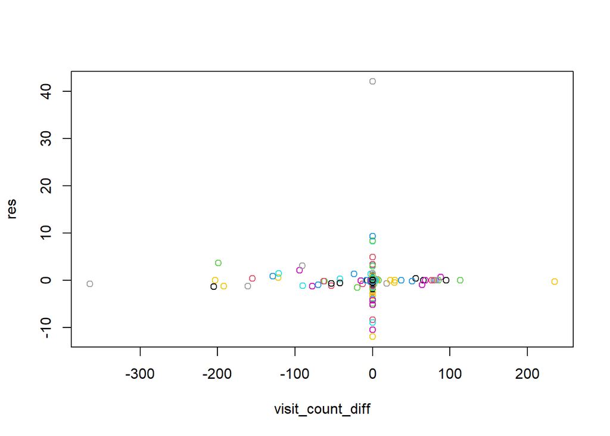

```r
product1_data[, `:=`(visit_count_diff, visit_count - shift(visit_count,
    7))]

product1_data[, `:=`(res, c(rep(NA, 7), as.numeric(product1_arima_model$residuals[1:365])))]

plot(product1_data[, list(visit_count_diff, res)], col = day(product1_data$event_date))
```

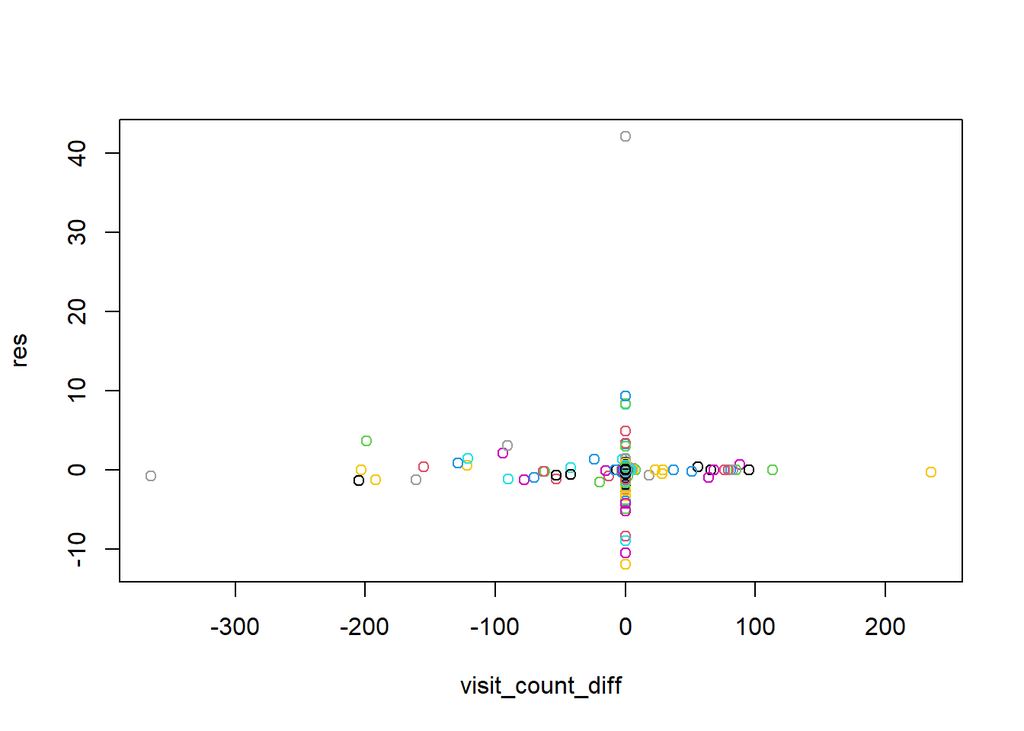

```r
product1_data[, `:=`(basket_count_diff, basket_count - shift(basket_count,
    7))]

product1_data[, `:=`(res, c(rep(NA, 7), as.numeric(product1_arima_model$residuals[1:365])))]

plot(product1_data[, list(visit_count_diff, res)], col = day(product1_data$event_date))
```

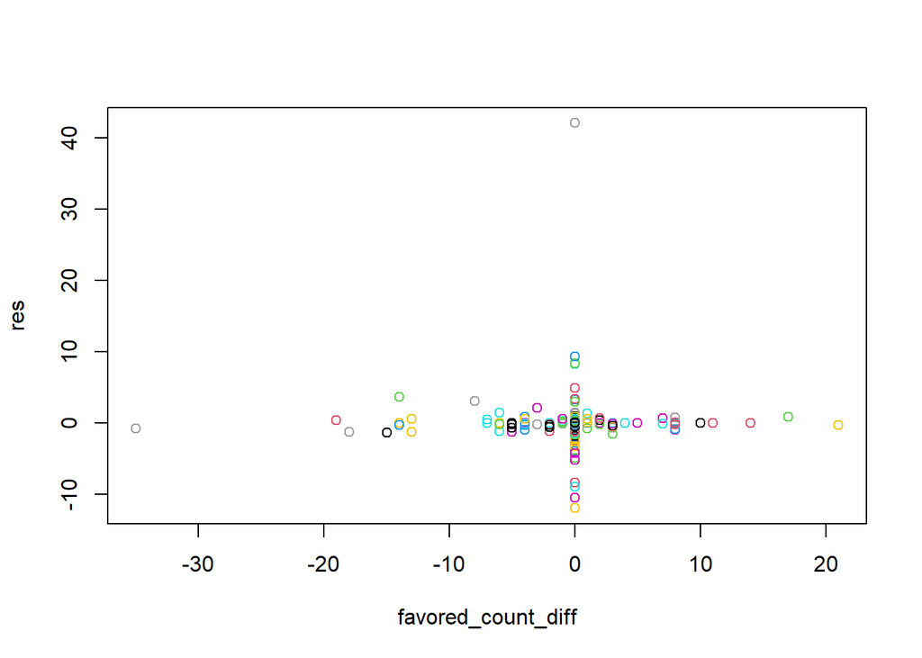

```r
product1_data[, `:=`(favored_count_diff, favored_count - shift(favored_count,
    7))]

product1_data[, `:=`(res, c(rep(NA, 7), as.numeric(product1_arima_model$residuals[1:365])))]

plot(product1_data[, list(favored_count_diff, res)], col = day(product1_data$event_date))
```

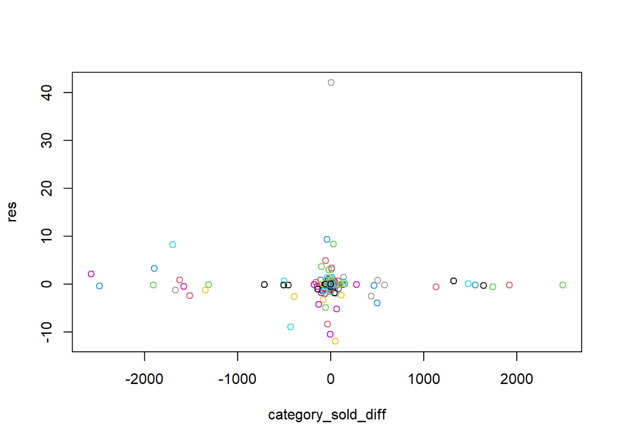

```r
product1_data[, `:=`(category_sold_diff, category_sold - shift(category_sold,
    7))]

product1_data[, `:=`(res, c(rep(NA, 7), as.numeric(product1_arima_model$residuals[1:365])))]

plot(product1_data[, list(category_sold_diff, res)], col = day(product1_data$event_date))
```

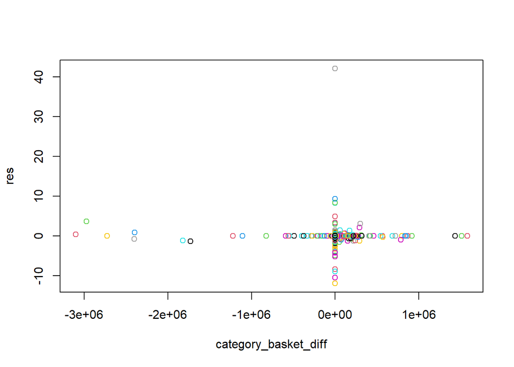

```r
product1_data[, `:=`(category_basket_diff, category_basket -
    shift(category_basket, 7))]

product1_data[, `:=`(res, c(rep(NA, 7), as.numeric(product1_arima_model$residuals[1:365])))]

plot(product1_data[, list(category_basket_diff, res)], col = day(product1_data$event_date))
```

There are lots of missing values on the Product1 data. Therefore, it’s hard to find a relationship between regressors and residuals.

```r
product1_data[is.na(price_diff) == T, `:=`(price_diff, 0)]
price_diff_mat_p1 <- matrix(product1_data$price_diff)
arimax_product1 = auto.arima(product1_data$sold_count, xreg = price_diff_mat_p1,
    seasonal = T, trace = T, stepwise = F, approximation = F)
```

```
##
##  ARIMA(0,0,0) with zero mean     : 2011.946
##  ARIMA(0,0,0) with non-zero mean : 1993.988
##  ARIMA(0,0,1) with zero mean     : 1947.225
##  ARIMA(0,0,1) with non-zero mean : 1936.938
##  ARIMA(0,0,2) with zero mean     : 1942.397
##  ARIMA(0,0,2) with non-zero mean : 1934.058
##  ARIMA(0,0,3) with zero mean     : 1928.233
##  ARIMA(0,0,3) with non-zero mean : 1922.884
##  ARIMA(0,0,4) with zero mean     : 1927.623
##  ARIMA(0,0,4) with non-zero mean : 1921.127
##  ARIMA(0,0,5) with zero mean     : 1923.841
##  ARIMA(0,0,5) with non-zero mean : 1918.159
##  ARIMA(1,0,0) with zero mean     : 1932.64
##  ARIMA(1,0,0) with non-zero mean : 1926.603
##  ARIMA(1,0,1) with zero mean     : 1931.647
##  ARIMA(1,0,1) with non-zero mean : 1927.301
##  ARIMA(1,0,2) with zero mean     : 1911.999
##  ARIMA(1,0,2) with non-zero mean : 1912.7
##  ARIMA(1,0,3) with zero mean     : 1924.746
##  ARIMA(1,0,3) with non-zero mean : 1918.114
##  ARIMA(1,0,4) with zero mean     : 1926.713
##  ARIMA(1,0,4) with non-zero mean : 1920.203
##  ARIMA(2,0,0) with zero mean     : 1932.882
##  ARIMA(2,0,0) with non-zero mean : 1927.751
##  ARIMA(2,0,1) with zero mean     : 1913.405
##  ARIMA(2,0,1) with non-zero mean : 1914.101
##  ARIMA(2,0,2) with zero mean     : 1908.487
##  ARIMA(2,0,2) with non-zero mean : 1909.145
##  ARIMA(2,0,3) with zero mean     : 1907.64
##  ARIMA(2,0,3) with non-zero mean : 1908.355
##  ARIMA(3,0,0) with zero mean     : 1931.996
##  ARIMA(3,0,0) with non-zero mean : 1927.914
##  ARIMA(3,0,1) with zero mean     : 1922.155
##  ARIMA(3,0,1) with non-zero mean : 1917.875
##  ARIMA(3,0,2) with zero mean     : 1906.838
##  ARIMA(3,0,2) with non-zero mean : 1907.562
##  ARIMA(4,0,0) with zero mean     : 1934.044
##  ARIMA(4,0,0) with non-zero mean : 1929.788
##  ARIMA(4,0,1) with zero mean     : 1923.672
##  ARIMA(4,0,1) with non-zero mean : 1918.782
##  ARIMA(5,0,0) with zero mean     : 1913.727
##  ARIMA(5,0,0) with non-zero mean : 1911.807
##
##
##
##  Best model: Regression with ARIMA(3,0,2) errors
```

##Product2 ARIMAX

Product2’s price is constant most of the time. Therefore, it doesn’t make sense to add price as regressor. Instead, we will check the category_sold, visit_count and favored_count as potential regressors. We can’t check the basket_count since it’s full with NA values.

Since we decomposed weekly, we are checking the weekly differences of potential regressors.

###Category_sold

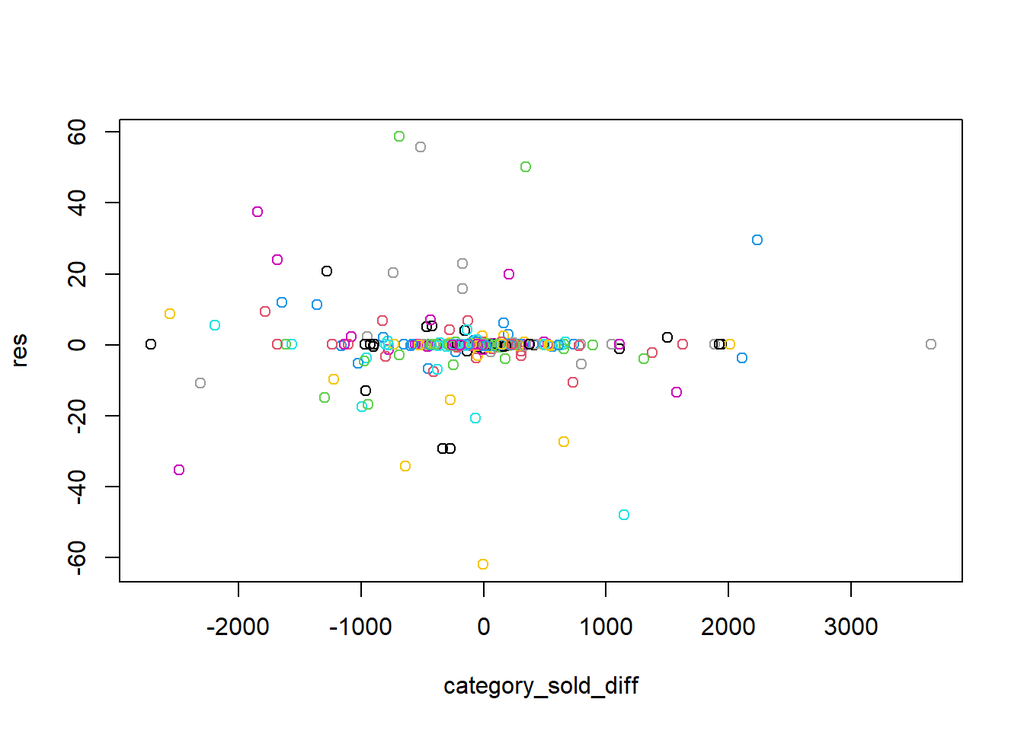

```r
product2_data[, `:=`(category_sold_diff, category_sold - shift(category_sold,
    7))]

product2_data[, `:=`(res, c(rep(NA, 7), as.numeric(product2_arima_model$residuals[1:365])))]

plot(product2_data[, list(category_sold_diff, res)], col = day(product2_data$event_date))
```

It doesn’t seem that there is a relationship between residuals and weekly category_sold differencing.

### Visit_count

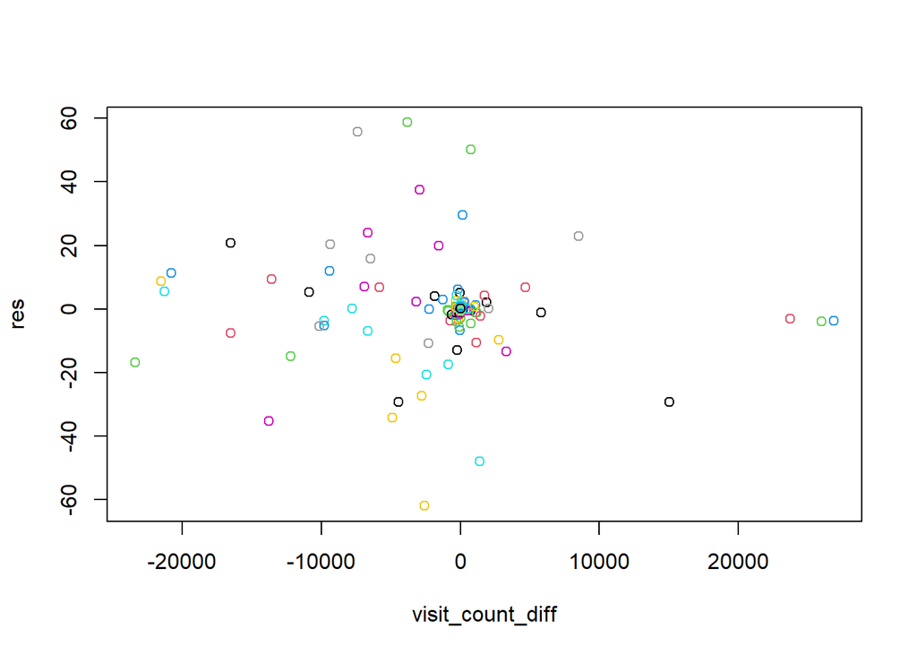

```r
product2_data[, `:=`(visit_count_diff, visit_count - shift(visit_count,
    7))]


product2_data[, `:=`(res, c(rep(NA, 7), as.numeric(product2_arima_model$residuals[1:365])))]

plot(product2_data[, list(visit_count_diff, res)], col = day(product2_data$event_date))
```

There doesn’t seem a relation again.

### Favored_count

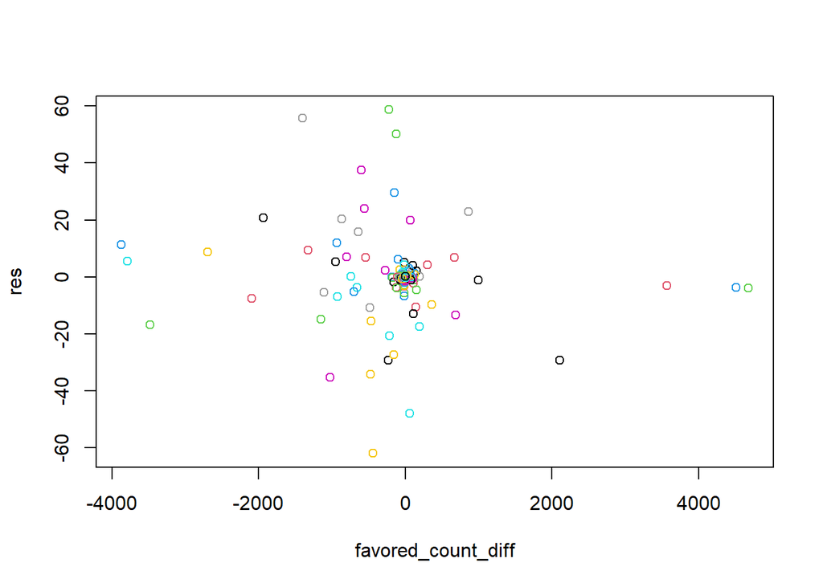

```r
product2_data[, `:=`(favored_count_diff, favored_count - shift(favored_count,
    7))]


product2_data[, `:=`(res, c(rep(NA, 7), as.numeric(product2_arima_model$residuals[1:365])))]

plot(product2_data[, list(favored_count_diff, res)], col = day(product2_data$event_date))
```

We can’t see a clear relationship again. Visually, it looks like visit_count_diff seems best to go with among these 3 alternatives.

```r
product2_data[is.na(visit_count_diff) == T, `:=`(visit_count_diff,
    0)]
visit_count_diff_mat_p2 <- matrix(product1_data$visit_count_diff)
arimax_product2 = auto.arima(product2_data$sold_count, xreg = visit_count_diff_mat_p2,
    seasonal = T, trace = T, stepwise = F, approximation = F)
```

```
##
##  ARIMA(0,1,0)                    : 2878.313
##  Regression with ARIMA(0,1,0) errors : 2879.804
##  ARIMA(0,1,1)                    : 2864.49
##  Regression with ARIMA(0,1,1) errors : 2865.415
##  ARIMA(0,1,2)                    : 2851.691
##  Regression with ARIMA(0,1,2) errors : 2852.139
##  ARIMA(0,1,3)                    : 2852.403
##  Regression with ARIMA(0,1,3) errors : 2853.04
##  ARIMA(0,1,4)                    : 2853.9
##  Regression with ARIMA(0,1,4) errors : 2854.473
##  ARIMA(0,1,5)                    : 2817.056
##  Regression with ARIMA(0,1,5) errors : 2817.206
##  ARIMA(1,1,0)                    : 2871.023
##  Regression with ARIMA(1,1,0) errors : 2872.262
##  ARIMA(1,1,1)                    : 2859.361
##  Regression with ARIMA(1,1,1) errors : 2859.766
##  ARIMA(1,1,2)                    : 2852.651
##  Regression with ARIMA(1,1,2) errors : 2853.212
##  ARIMA(1,1,3)                    : 2854.425
##  Regression with ARIMA(1,1,3) errors : 2855.072
##  ARIMA(1,1,4)                    : 2850.092
##  Regression with ARIMA(1,1,4) errors : 2850.348
##  ARIMA(2,1,0)                    : 2847.763
##  Regression with ARIMA(2,1,0) errors : 2848.405
##  ARIMA(2,1,1)                    : 2846.962
##  Regression with ARIMA(2,1,1) errors : 2847.698
##  ARIMA(2,1,2)                    : Inf
##  Regression with ARIMA(2,1,2) errors : Inf
##  ARIMA(2,1,3)                    : 2837.214
##  Regression with ARIMA(2,1,3) errors : 2838.285
##  ARIMA(3,1,0)                    : 2845.51
##  Regression with ARIMA(3,1,0) errors : 2846.365
##  ARIMA(3,1,1)                    : 2847.575
##  Regression with ARIMA(3,1,1) errors : 2848.442
##  ARIMA(3,1,2)                    : 2837.905
##  Regression with ARIMA(3,1,2) errors : 2838.937
##  ARIMA(4,1,0)                    : 2847.569
##  Regression with ARIMA(4,1,0) errors : 2848.44
##  ARIMA(4,1,1)                    : 2844.678
##  Regression with ARIMA(4,1,1) errors : 2844.963
##  ARIMA(5,1,0)                    : 2835.786
##  Regression with ARIMA(5,1,0) errors : 2836.318
##
##
##
##  Best model: Regression with ARIMA(0,1,5) errors
```

##Product3 ARIMAX

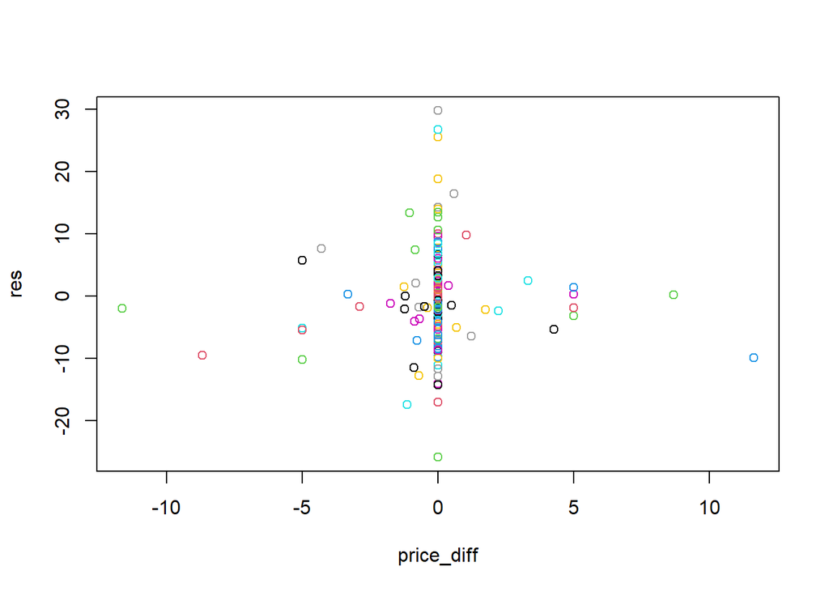

```r
product3_data[, `:=`(price_diff, price - shift(price, 7))]

product3_data[, `:=`(res, c(rep(NA, 7), as.numeric(product3_arima_model$residuals[1:365])))]

plot(product3_data[, list(price_diff, res)], col = day(product3_data$event_date))
```

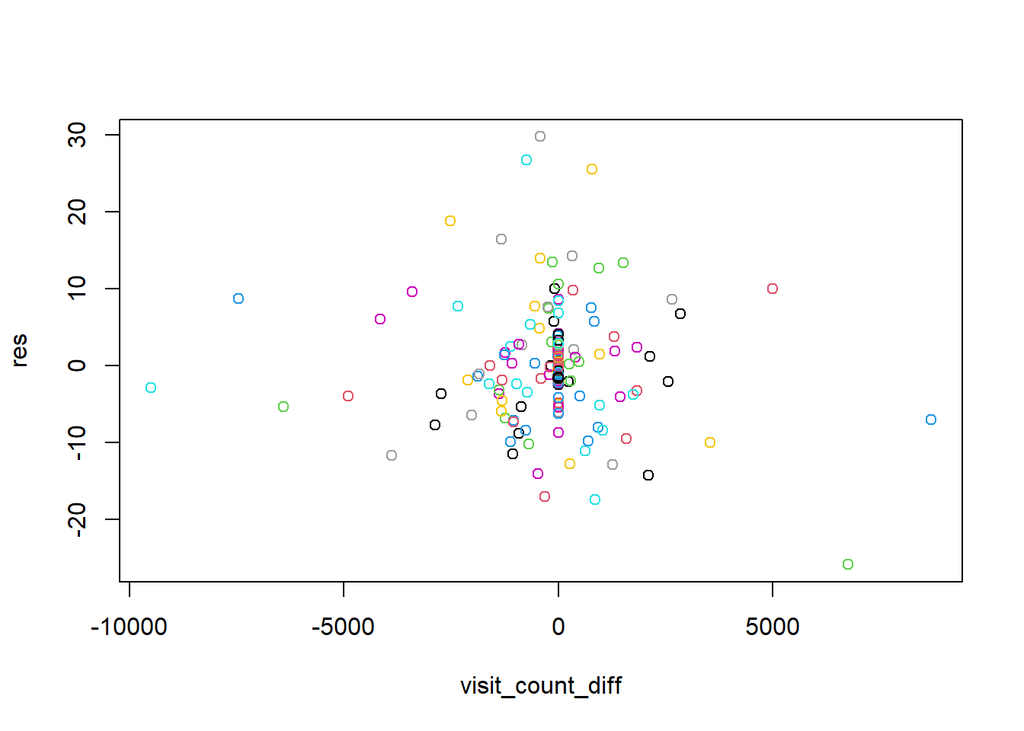

```r
product3_data[, `:=`(visit_count_diff, visit_count - shift(visit_count,
    7))]
plot(product3_data[, list(visit_count_diff, res)], col = day(product3_data$event_date))
```

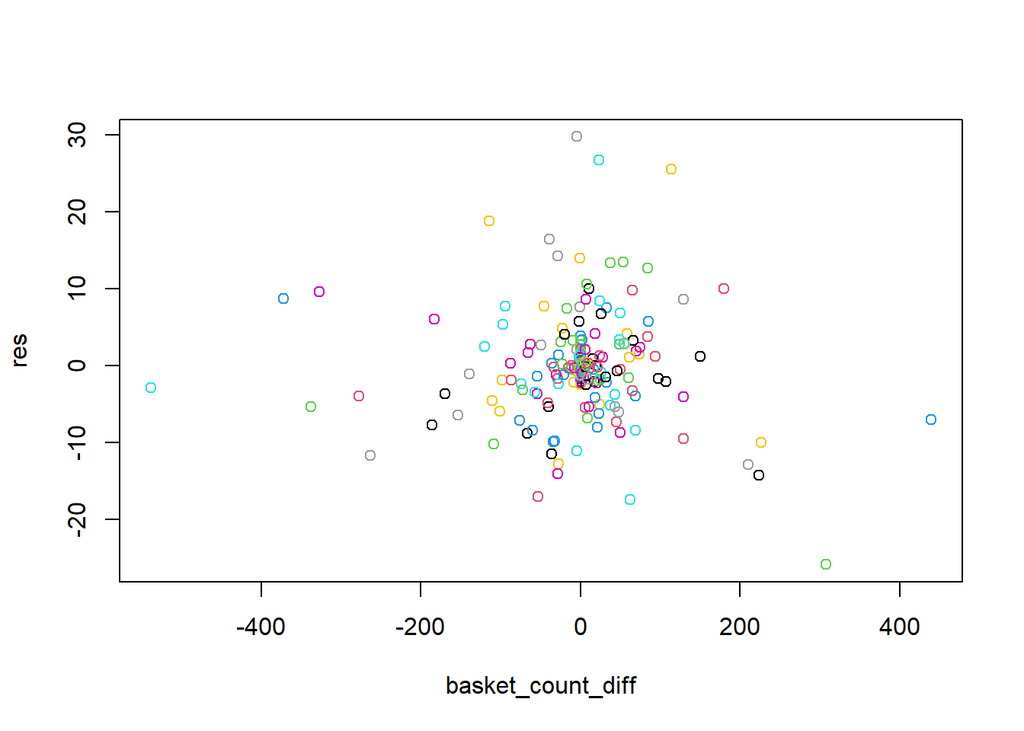

```r
product3_data[, `:=`(basket_count_diff, basket_count - shift(basket_count,
    7))]
plot(product3_data[, list(basket_count_diff, res)], col = day(product3_data$event_date))
```

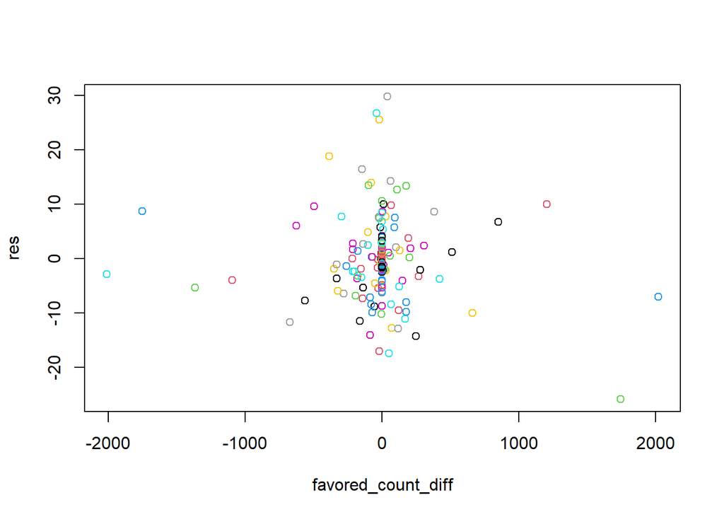

```r
product3_data[, `:=`(favored_count_diff, favored_count - shift(favored_count,
    7))]
plot(product3_data[, list(favored_count_diff, res)], col = day(product3_data$event_date))
```

```r
product3_data[is.na(basket_count) == T, `:=`(basket_count, 0)]
basket_count_mat_p3 <- matrix(product3_data$basket_count)
arimax_product3 = auto.arima(product3_data$sold_count, xreg = basket_count_mat_p3,
    seasonal = T, trace = T, stepwise = F, approximation = F)
```

```
##
##  ARIMA(0,0,0) with zero mean     : 2303.674
##  ARIMA(0,0,0) with non-zero mean : 2303.081
##  ARIMA(0,0,1) with zero mean     : 2221.798
##  ARIMA(0,0,1) with non-zero mean : 2221.676
##  ARIMA(0,0,2) with zero mean     : 2217.999
##  ARIMA(0,0,2) with non-zero mean : 2217.773
##  ARIMA(0,0,3) with zero mean     : 2216.895
##  ARIMA(0,0,3) with non-zero mean : 2217.031
##  ARIMA(0,0,4) with zero mean     : 2216.274
##  ARIMA(0,0,4) with non-zero mean : 2216.338
##  ARIMA(0,0,5) with zero mean     : 2207.519
##  ARIMA(0,0,5) with non-zero mean : 2208.101
##  ARIMA(1,0,0) with zero mean     : 2211.654
##  ARIMA(1,0,0) with non-zero mean : 2211.651
##  ARIMA(1,0,1) with zero mean     : 2213.669
##  ARIMA(1,0,1) with non-zero mean : 2213.657
##  ARIMA(1,0,2) with zero mean     : Inf
##  ARIMA(1,0,2) with non-zero mean : 2192.597
##  ARIMA(1,0,3) with zero mean     : Inf
##  ARIMA(1,0,3) with non-zero mean : 2194.232
##  ARIMA(1,0,4) with zero mean     : Inf
##  ARIMA(1,0,4) with non-zero mean : 2192.68
##  ARIMA(2,0,0) with zero mean     : 2213.687
##  ARIMA(2,0,0) with non-zero mean : 2213.687
##  ARIMA(2,0,1) with zero mean     : Inf
##  ARIMA(2,0,1) with non-zero mean : 2199.563
##  ARIMA(2,0,2) with zero mean     : Inf
##  ARIMA(2,0,2) with non-zero mean : 2194.411
##  ARIMA(2,0,3) with zero mean     : 2193.684
##  ARIMA(2,0,3) with non-zero mean : 2185.4
##  ARIMA(3,0,0) with zero mean     : 2206.848
##  ARIMA(3,0,0) with non-zero mean : 2207.107
##  ARIMA(3,0,1) with zero mean     : Inf
##  ARIMA(3,0,1) with non-zero mean : 2191.253
##  ARIMA(3,0,2) with zero mean     : 2180.082
##  ARIMA(3,0,2) with non-zero mean : 2180.692
##  ARIMA(4,0,0) with zero mean     : 2202.974
##  ARIMA(4,0,0) with non-zero mean : 2202.874
##  ARIMA(4,0,1) with zero mean     : Inf
##  ARIMA(4,0,1) with non-zero mean : 2192.681
##  ARIMA(5,0,0) with zero mean     : 2201.788
##  ARIMA(5,0,0) with non-zero mean : 2201.751
##
##
##
##  Best model: Regression with ARIMA(3,0,2) errors
```

##Product4 ARIMAX

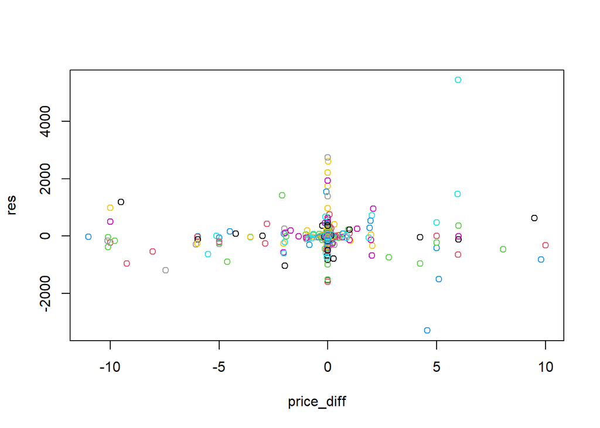

```r
product4_data[, `:=`(price_diff, price - shift(price, 7))]

product4_data[, `:=`(res, c(rep(NA, 7), as.numeric(product4_arima_model$residuals[1:365])))]

plot(product4_data[, list(price_diff, res)], col = day(product4_data$event_date))
```

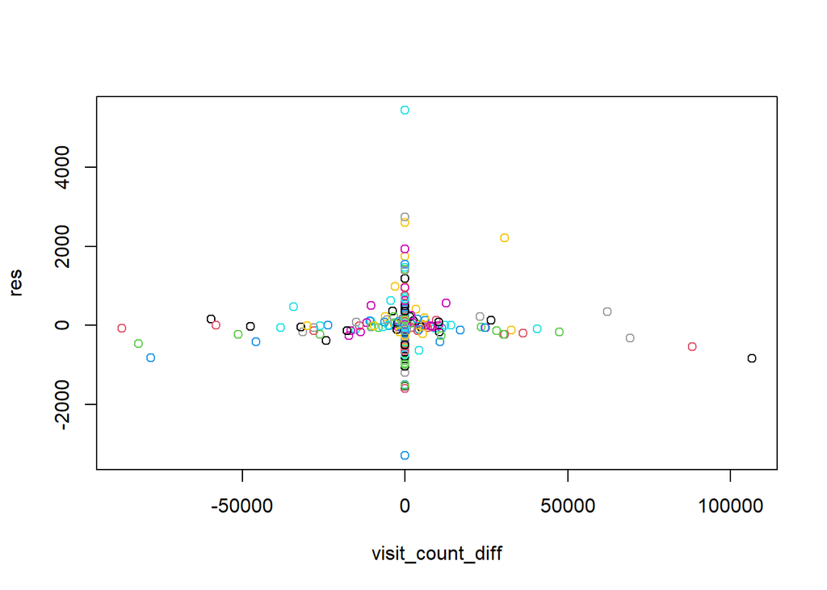

```r
product4_data[, `:=`(visit_count_diff, visit_count - shift(visit_count,
    7))]
plot(product4_data[, list(visit_count_diff, res)], col = day(product4_data$event_date))
```

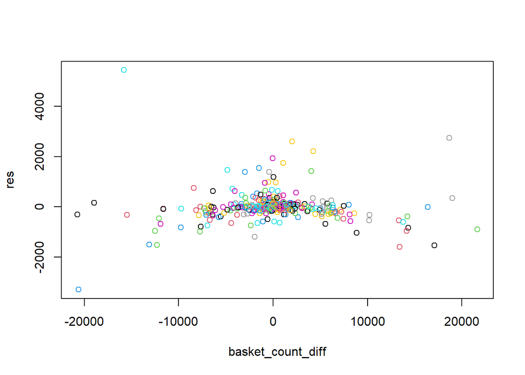

```r
product4_data[, `:=`(basket_count_diff, basket_count - shift(basket_count,
    7))]
plot(product4_data[, list(basket_count_diff, res)], col = day(product4_data$event_date))
```

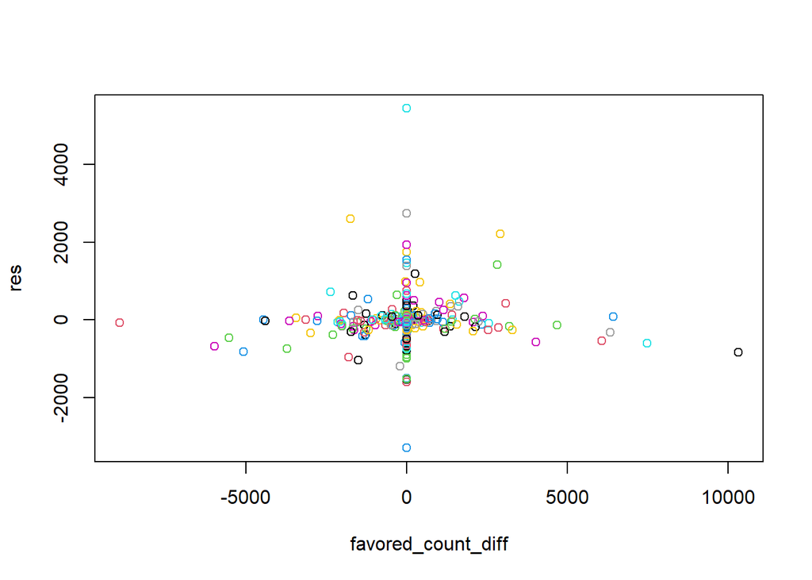

```r
product4_data[, `:=`(favored_count_diff, favored_count - shift(favored_count,
    7))]
plot(product4_data[, list(favored_count_diff, res)], col = day(product4_data$event_date))
```

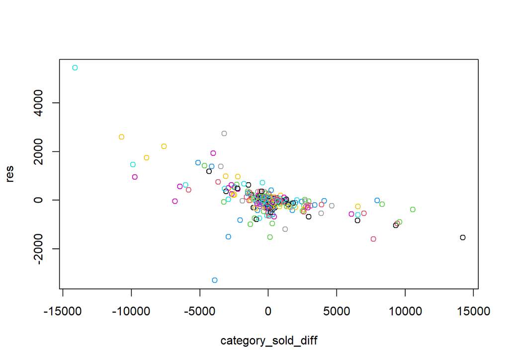

```r
product4_data[, `:=`(category_sold_diff, category_sold - shift(category_sold,
    4))]
plot(product4_data[, list(category_sold_diff, res)], col = day(product4_data$event_date))
```

We see a decreasing residual trend with the increasing category_sold_differencing levels. Notice here the rate is not 7 but 4.

```r
product4_data[is.na(category_sold_diff) == T, `:=`(category_sold_diff,
    0)]
category_sold_diff_mat_p4 <- matrix(product4_data$category_sold_diff)
arimax_product4 = auto.arima(product4_data$sold_count, xreg = category_sold_diff_mat_p4,
    seasonal = T, trace = T, stepwise = F, approximation = F)
```

```
##
##  ARIMA(0,1,0)                    : 5669.004
##  Regression with ARIMA(0,1,0) errors : 5671.036
##  ARIMA(0,1,1)                    : 5664.402
##  Regression with ARIMA(0,1,1) errors : 5666.445
##  ARIMA(0,1,2)                    : 5665.855
##  Regression with ARIMA(0,1,2) errors : 5667.909
##  ARIMA(0,1,3)                    : 5663.487
##  Regression with ARIMA(0,1,3) errors : 5665.553
##  ARIMA(0,1,4)                    : 5648.298
##  Regression with ARIMA(0,1,4) errors : 5650.366
##  ARIMA(0,1,5)                    : 5615.193
##  Regression with ARIMA(0,1,5) errors : 5617.282
##  ARIMA(1,1,0)                    : 5664.959
##  Regression with ARIMA(1,1,0) errors : 5667.001
##  ARIMA(1,1,1)                    : 5638.573
##  Regression with ARIMA(1,1,1) errors : 5640.628
##  ARIMA(1,1,2)                    : 5640.523
##  Regression with ARIMA(1,1,2) errors : 5642.589
##  ARIMA(1,1,3)                    : 5651.508
##  Regression with ARIMA(1,1,3) errors : 5653.585
##  ARIMA(1,1,4)                    : 5642.272
##  Regression with ARIMA(1,1,4) errors : 5644.355
##  ARIMA(2,1,0)                    : 5666.475
##  Regression with ARIMA(2,1,0) errors : 5668.529
##  ARIMA(2,1,1)                    : 5640.504
##  Regression with ARIMA(2,1,1) errors : 5642.571
##  ARIMA(2,1,2)                    : 5638.239
##  Regression with ARIMA(2,1,2) errors : 5640.569
##  ARIMA(2,1,3)                    : 5637.833
##  Regression with ARIMA(2,1,3) errors : 5639.921
##  ARIMA(3,1,0)                    : 5663.66
##  Regression with ARIMA(3,1,0) errors : 5665.725
##  ARIMA(3,1,1)                    : 5659.539
##  Regression with ARIMA(3,1,1) errors : 5661.614
##  ARIMA(3,1,2)                    : 5632.567
##  Regression with ARIMA(3,1,2) errors : 5634.654
##  ARIMA(4,1,0)                    : 5659.181
##  Regression with ARIMA(4,1,0) errors : 5661.256
##  ARIMA(4,1,1)                    : 5658.582
##  Regression with ARIMA(4,1,1) errors : 5660.668
##  ARIMA(5,1,0)                    : 5655.374
##  Regression with ARIMA(5,1,0) errors : 5657.462
##
##
##
##  Best model: Regression with ARIMA(0,1,5) errors
```

##Product5 ARIMAX

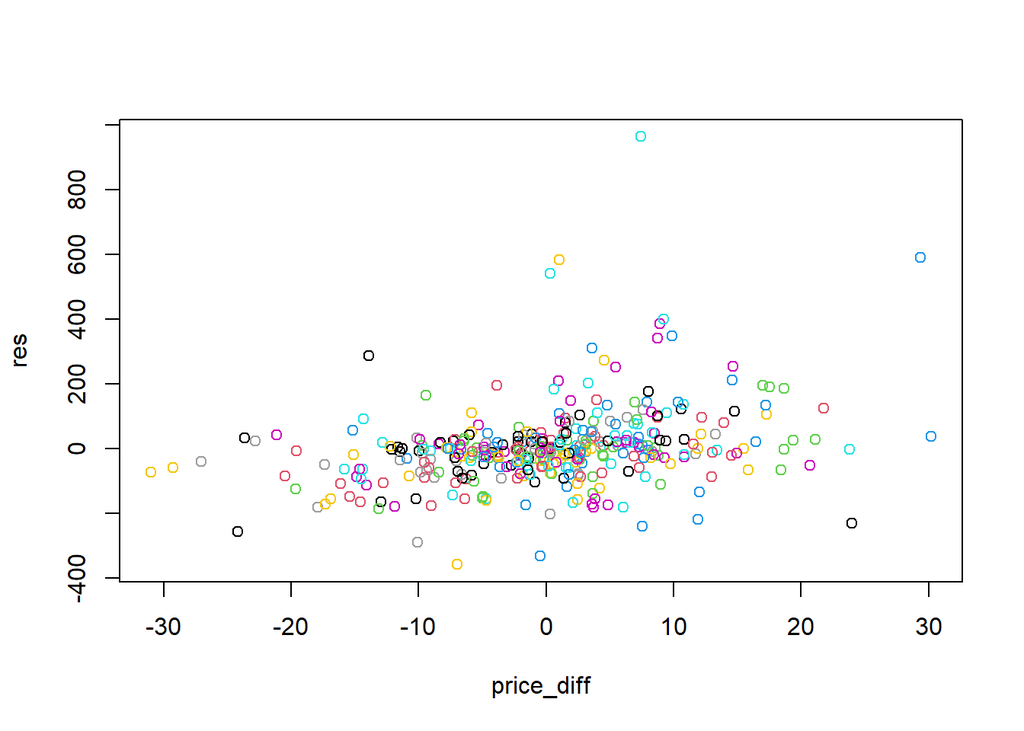

```r
product5_data[, `:=`(price_diff, price - shift(price, 4))]

product5_data[, `:=`(res, c(rep(NA, 7), as.numeric(product5_arima_model$residuals[1:365])))]

plot(product5_data[, list(price_diff, res)], col = day(product5_data$event_date))
```

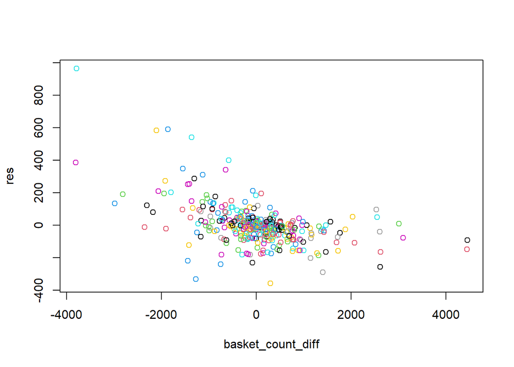

```r
product5_data[, `:=`(basket_count_diff, basket_count - shift(basket_count,
    4))]
plot(product5_data[, list(basket_count_diff, res)], col = day(product5_data$event_date))
```

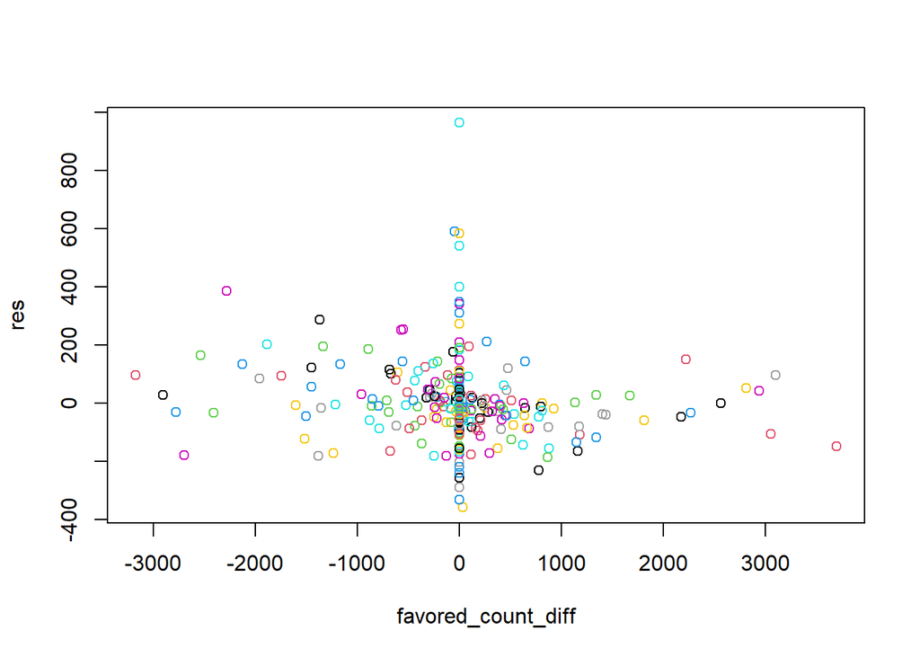

```r
product5_data[, `:=`(favored_count_diff, favored_count - shift(favored_count,
    4))]
plot(product5_data[, list(favored_count_diff, res)], col = day(product5_data$event_date))
```

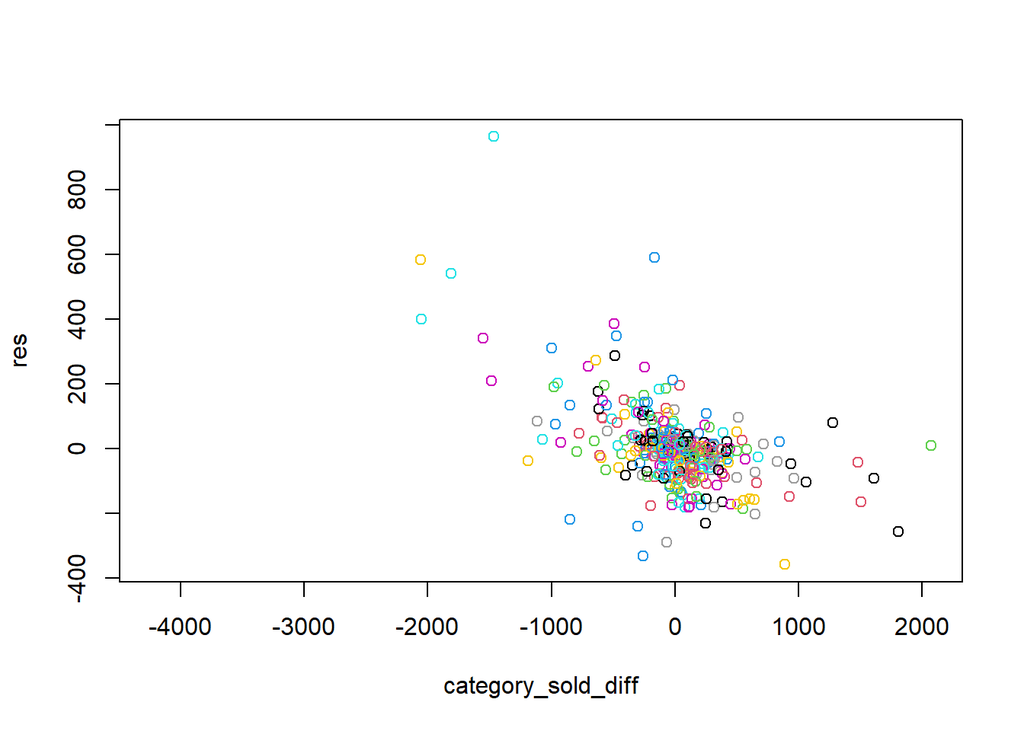

```r
product5_data[, `:=`(category_sold_diff, category_sold - shift(category_sold,
    4))]
plot(product5_data[, list(category_sold_diff, res)], col = day(product5_data$event_date))
```

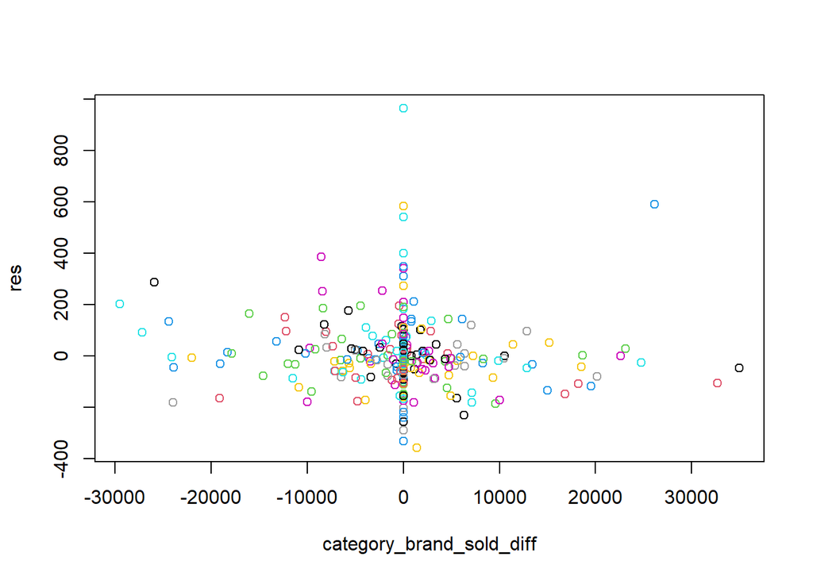

```r
product5_data[, `:=`(category_brand_sold_diff, category_brand_sold -
    shift(category_brand_sold, 4))]
plot(product5_data[, list(category_brand_sold_diff, res)], col = day(product5_data$event_date))
```

With 4 levels of differencing, we can see trends in residuals.

```r
arima_p5 <- arima(product5_data$sold_count, order = c(1, 0, 1),
    seasonal = c(1, 0, 1))
product5_data[, `:=`(residuals, residuals(arima_p5))]
residuals_mat_p5 <- matrix(product5_data$residuals)
arimax_product5 = auto.arima(product5_data$sold_count, xreg = residuals_mat_p5,
    seasonal = T, trace = T, stepwise = F, approximation = F)
```

```
##
##  ARIMA(0,0,0) with zero mean     : 5556.707
##  ARIMA(0,0,0) with non-zero mean : 4817.509
##  ARIMA(0,0,1) with zero mean     : Inf
##  ARIMA(0,0,1) with non-zero mean : Inf
##  ARIMA(0,0,2) with zero mean     : 4696.098
##  ARIMA(0,0,2) with non-zero mean : Inf
##  ARIMA(0,0,3) with zero mean     : Inf
##  ARIMA(0,0,3) with non-zero mean : Inf
##  ARIMA(0,0,4) with zero mean     : Inf
##  ARIMA(0,0,4) with non-zero mean : Inf
##  ARIMA(0,0,5) with zero mean     : Inf
##  ARIMA(0,0,5) with non-zero mean : Inf
##  ARIMA(1,0,0) with zero mean     : 4335.941
##  ARIMA(1,0,0) with non-zero mean : 4315.347
##  ARIMA(1,0,1) with zero mean     : Inf
##  ARIMA(1,0,1) with non-zero mean : Inf
##  ARIMA(1,0,2) with zero mean     : Inf
##  ARIMA(1,0,2) with non-zero mean : Inf
##  ARIMA(1,0,3) with zero mean     : Inf
##  ARIMA(1,0,3) with non-zero mean : Inf
##  ARIMA(1,0,4) with zero mean     : Inf
##  ARIMA(1,0,4) with non-zero mean : Inf
##  ARIMA(2,0,0) with zero mean     : 4253.731
##  ARIMA(2,0,0) with non-zero mean : 4193.825
##  ARIMA(2,0,1) with zero mean     : Inf
##  ARIMA(2,0,1) with non-zero mean : Inf
##  ARIMA(2,0,2) with zero mean     : Inf
##  ARIMA(2,0,2) with non-zero mean : Inf
##  ARIMA(2,0,3) with zero mean     : Inf
##  ARIMA(2,0,3) with non-zero mean : Inf
##  ARIMA(3,0,0) with zero mean     : 4181.257
##  ARIMA(3,0,0) with non-zero mean : 4153.968
##  ARIMA(3,0,1) with zero mean     : Inf
##  ARIMA(3,0,1) with non-zero mean : Inf
##  ARIMA(3,0,2) with zero mean     : Inf
##  ARIMA(3,0,2) with non-zero mean : Inf
##  ARIMA(4,0,0) with zero mean     : 4181.667
##  ARIMA(4,0,0) with non-zero mean : 4147.894
##  ARIMA(4,0,1) with zero mean     : Inf
##  ARIMA(4,0,1) with non-zero mean : Inf
##  ARIMA(5,0,0) with zero mean     : 4157.536
##  ARIMA(5,0,0) with non-zero mean : 4136.147
##
##
##
##  Best model: Regression with ARIMA(5,0,0) errors
```

##Product6 ARIMAX

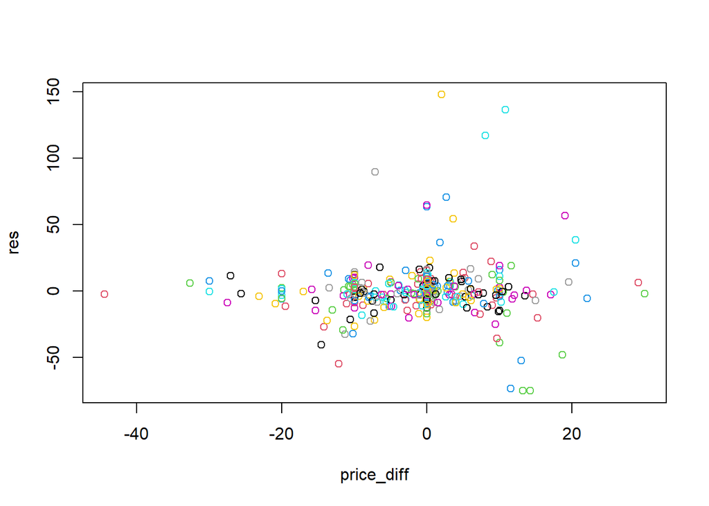

```r
product6_data[, `:=`(price_diff, price - shift(price, 7))]
product6_data[, `:=`(res, c(rep(NA, 7), as.numeric(product6_arima_model$residuals[1:365])))]

plot(product6_data[, list(price_diff, res)], col = day(product6_data$event_date))
```

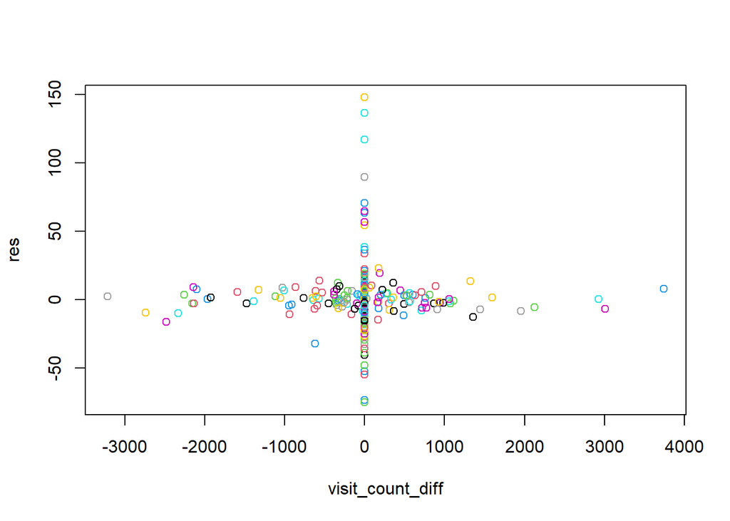

```r
product6_data[, `:=`(visit_count_diff, visit_count - shift(visit_count,
    7))]
plot(product6_data[, list(visit_count_diff, res)], col = day(product6_data$event_date))
```

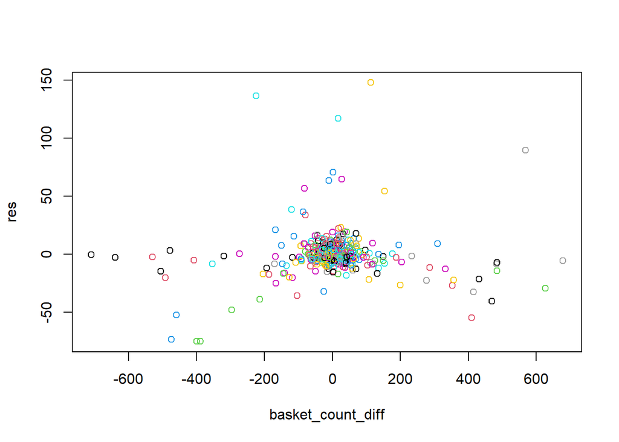

```r
product6_data[, `:=`(basket_count_diff, basket_count - shift(basket_count,
    7))]
plot(product6_data[, list(basket_count_diff, res)], col = day(product6_data$event_date))
```

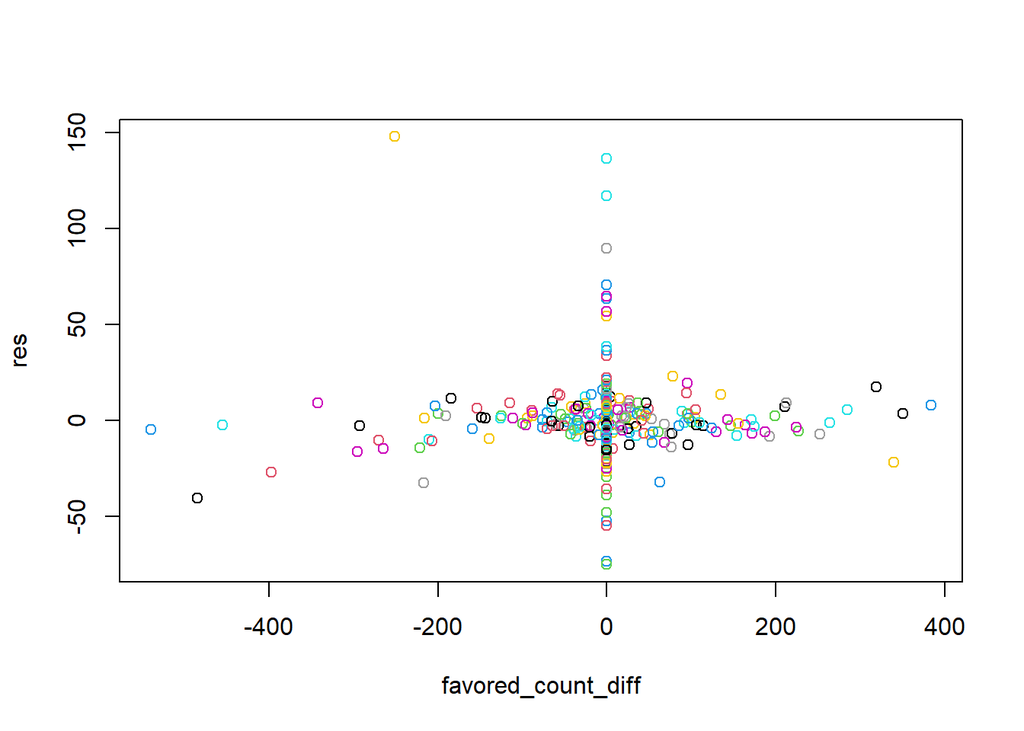

```r
product6_data[, `:=`(favored_count_diff, favored_count - shift(favored_count,
    7))]
plot(product6_data[, list(favored_count_diff, res)], col = day(product6_data$event_date))
```

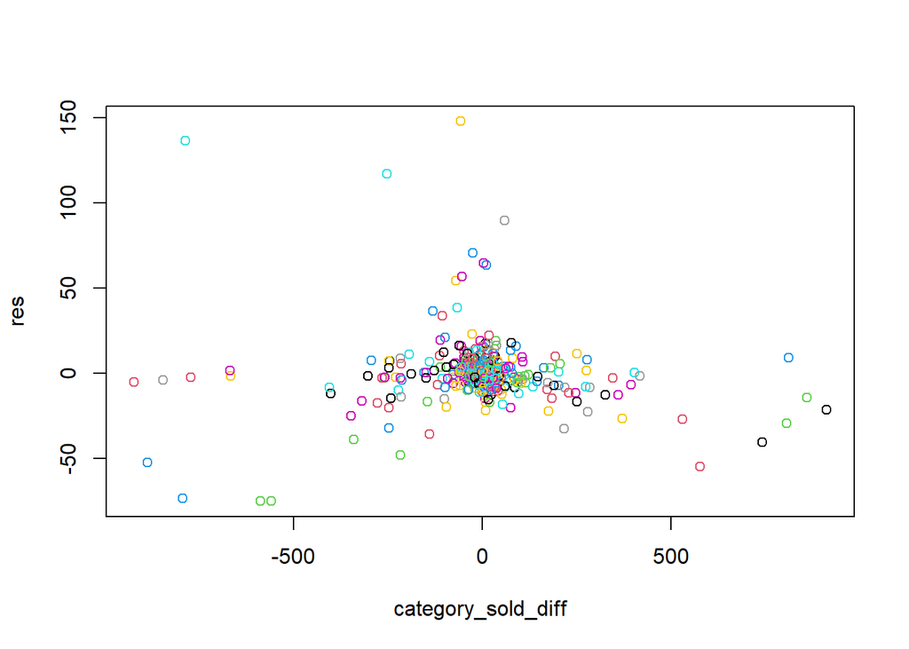

```r
product6_data[, `:=`(category_sold_diff, category_sold - shift(category_sold,
    7))]
plot(product6_data[, list(category_sold_diff, res)], col = day(product6_data$event_date))
```

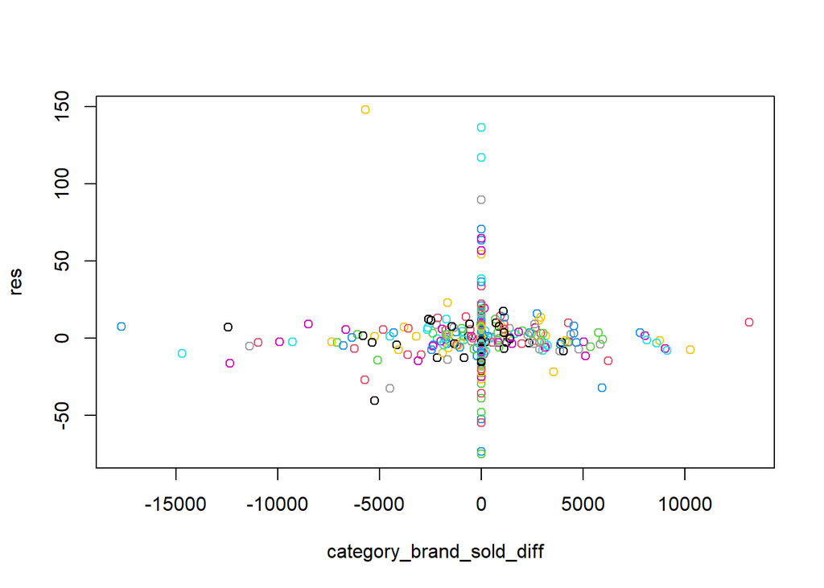

```r
product6_data[, `:=`(category_brand_sold_diff, category_brand_sold -
    shift(category_brand_sold, 7))]
plot(product6_data[, list(category_brand_sold_diff, res)], col = day(product6_data$event_date))
```

```r
product6_data[is.na(basket_count_diff) == T, `:=`(basket_count_diff,
    0)]
basket_count_diff_mat_p6 <- matrix(product6_data$basket_count_diff)
arimax_product6 = auto.arima(product6_data$sold_count, xreg = basket_count_diff_mat_p6,
    seasonal = T, trace = T, stepwise = F, approximation = F)
```

```
##
##  ARIMA(0,1,0)                    : 3451.13
##  Regression with ARIMA(0,1,0) errors : 3453.162
##  ARIMA(0,1,1)                    : 3419.629
##  Regression with ARIMA(0,1,1) errors : 3421.67
##  ARIMA(0,1,2)                    : 3395.61
##  Regression with ARIMA(0,1,2) errors : 3397.608
##  ARIMA(0,1,3)                    : 3371.232
##  Regression with ARIMA(0,1,3) errors : 3373.215
##  ARIMA(0,1,4)                    : 3357.304
##  Regression with ARIMA(0,1,4) errors : 3359.275
##  ARIMA(0,1,5)                    : 3357.529
##  Regression with ARIMA(0,1,5) errors : 3359.528
##  ARIMA(1,1,0)                    : 3422.638
##  Regression with ARIMA(1,1,0) errors : 3424.68
##  ARIMA(1,1,1)                    : 3379.96
##  Regression with ARIMA(1,1,1) errors : 3381.922
##  ARIMA(1,1,2)                    : 3381.409
##  Regression with ARIMA(1,1,2) errors : 3383.379
##  ARIMA(1,1,3)                    : 3366.678
##  Regression with ARIMA(1,1,3) errors : 3368.654
##  ARIMA(1,1,4)                    : 3356.009
##  Regression with ARIMA(1,1,4) errors : 3358.003
##  ARIMA(2,1,0)                    : 3424.438
##  Regression with ARIMA(2,1,0) errors : 3426.491
##  ARIMA(2,1,1)                    : 3380.865
##  Regression with ARIMA(2,1,1) errors : 3382.833
##  ARIMA(2,1,2)                    : 3381.591
##  Regression with ARIMA(2,1,2) errors : 3383.569
##  ARIMA(2,1,3)                    : 3342.867
##  Regression with ARIMA(2,1,3) errors : 3344.893
##  ARIMA(3,1,0)                    : 3425.571
##  Regression with ARIMA(3,1,0) errors : 3427.635
##  ARIMA(3,1,1)                    : 3370.159
##  Regression with ARIMA(3,1,1) errors : 3372.153
##  ARIMA(3,1,2)                    : 3358.712
##  Regression with ARIMA(3,1,2) errors : 3360.76
##  ARIMA(4,1,0)                    : 3368.522
##  Regression with ARIMA(4,1,0) errors : 3370.593
##  ARIMA(4,1,1)                    : 3338.49
##  Regression with ARIMA(4,1,1) errors : 3340.532
##  ARIMA(5,1,0)                    : 3358.375
##  Regression with ARIMA(5,1,0) errors : 3360.453
##
##
##
##  Best model: Regression with ARIMA(4,1,1) errors
```

##Product7 ARIMAX

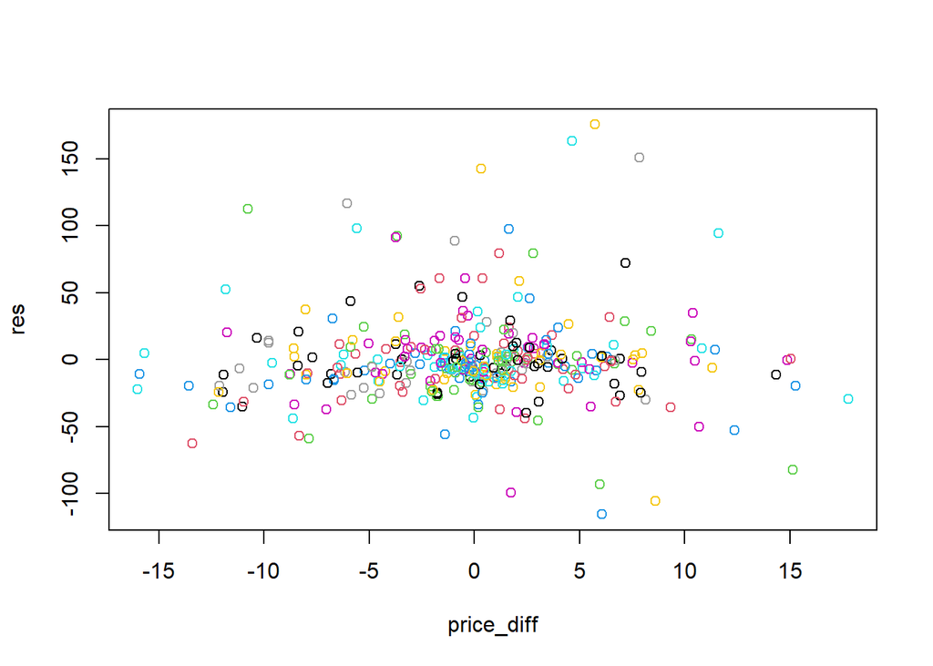

```r
product7_data[, `:=`(price_diff, price - shift(price, 7))]
product7_data[, `:=`(res, c(rep(NA, 7), as.numeric(product7_arima_model$residuals[1:365])))]

plot(product7_data[, list(price_diff, res)], col = day(product7_data$event_date))
```

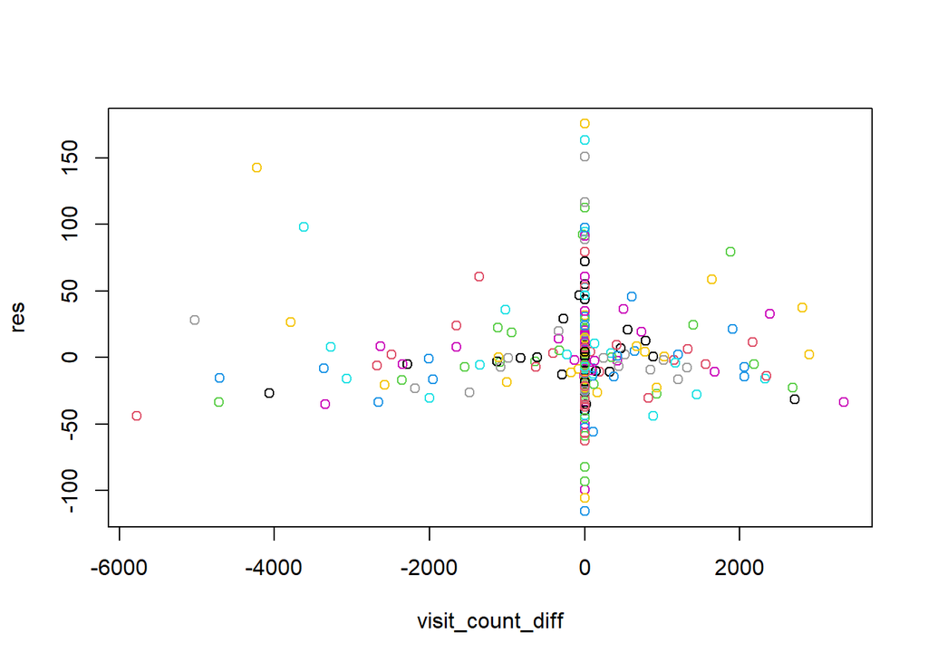

```r
product7_data[, `:=`(visit_count_diff, visit_count - shift(visit_count,
    7))]
plot(product7_data[, list(visit_count_diff, res)], col = day(product7_data$event_date))
```

```r
product7_data$basket_count
```

[output not shown]

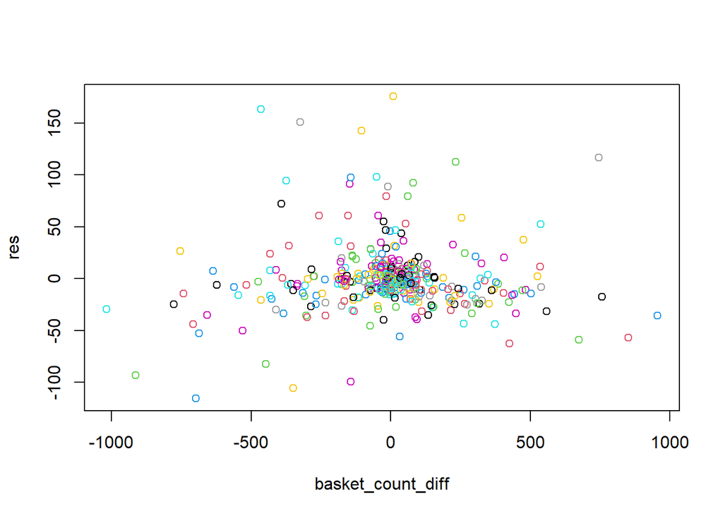

```r
product7_data[, `:=`(basket_count_diff, basket_count - shift(basket_count,
    7))]
plot(product7_data[, list(basket_count_diff, res)], col = day(product7_data$event_date))
```

```r
product7_data$favored_count
```

[output not shown]

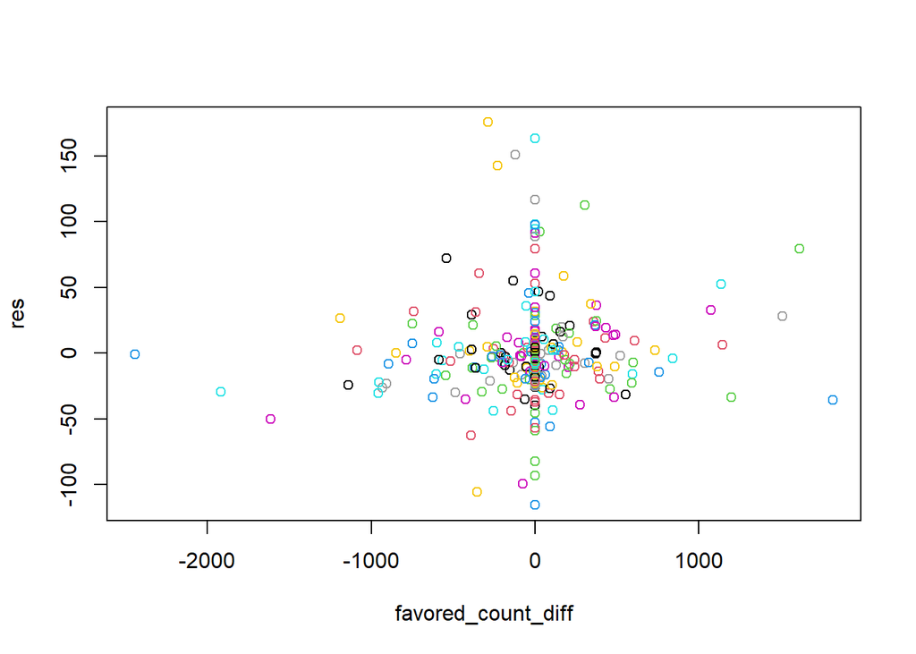

```r
product7_data[, `:=`(favored_count_diff, favored_count - shift(favored_count,
    7))]
plot(product7_data[, list(favored_count_diff, res)], col = day(product7_data$event_date))
```

```r
product7_data[is.na(visit_count) == T, `:=`(visit_count, 0)]
visit_count_mat_p7 <- matrix(product7_data$visit_count)
arimax_product7 = auto.arima(product7_data$sold_count, xreg = visit_count_mat_p7,
    seasonal = T, trace = T, stepwise = F, approximation = F)
```

```
##
##  ARIMA(0,0,0) with zero mean     : 4309.262
##  ARIMA(0,0,0) with non-zero mean : 4106.892
##  ARIMA(0,0,1) with zero mean     : 4058.455
##  ARIMA(0,0,1) with non-zero mean : 3920.888
##  ARIMA(0,0,2) with zero mean     : 3934.093
##  ARIMA(0,0,2) with non-zero mean : 3840.657
##  ARIMA(0,0,3) with zero mean     : 3860.807
##  ARIMA(0,0,3) with non-zero mean : 3797.017
##  ARIMA(0,0,4) with zero mean     : 3837.916
##  ARIMA(0,0,4) with non-zero mean : 3790.669
##  ARIMA(0,0,5) with zero mean     : 3836.41
##  ARIMA(0,0,5) with non-zero mean : 3792.748
##  ARIMA(1,0,0) with zero mean     : 3817.559
##  ARIMA(1,0,0) with non-zero mean : 3802.401
##  ARIMA(1,0,1) with zero mean     : 3819.597
##  ARIMA(1,0,1) with non-zero mean : 3803.811
##  ARIMA(1,0,2) with zero mean     : 3813.72
##  ARIMA(1,0,2) with non-zero mean : 3792.356
##  ARIMA(1,0,3) with zero mean     : 3815.729
##  ARIMA(1,0,3) with non-zero mean : 3790.374
##  ARIMA(1,0,4) with zero mean     : Inf
##  ARIMA(1,0,4) with non-zero mean : 3792.409
##  ARIMA(2,0,0) with zero mean     : 3819.596
##  ARIMA(2,0,0) with non-zero mean : 3803.499
##  ARIMA(2,0,1) with zero mean     : 3820.105
##  ARIMA(2,0,1) with non-zero mean : 3805.808
##  ARIMA(2,0,2) with zero mean     : 3815.77
##  ARIMA(2,0,2) with non-zero mean : 3792.118
##  ARIMA(2,0,3) with zero mean     : 3817.549
##  ARIMA(2,0,3) with non-zero mean : 3792.451
##  ARIMA(3,0,0) with zero mean     : 3816.403
##  ARIMA(3,0,0) with non-zero mean : 3793.059
##  ARIMA(3,0,1) with zero mean     : 3818.062
##  ARIMA(3,0,1) with non-zero mean : 3795.013
##  ARIMA(3,0,2) with zero mean     : 3810.633
##  ARIMA(3,0,2) with non-zero mean : 3790.374
##  ARIMA(4,0,0) with zero mean     : 3817.132
##  ARIMA(4,0,0) with non-zero mean : 3794.901
##  ARIMA(4,0,1) with zero mean     : Inf
##  ARIMA(4,0,1) with non-zero mean : 3796.461
##  ARIMA(5,0,0) with zero mean     : 3811.272
##  ARIMA(5,0,0) with non-zero mean : 3794.64
##
##
##
##  Best model: Regression with ARIMA(3,0,2) errors
```

##Product8 ARIMAX

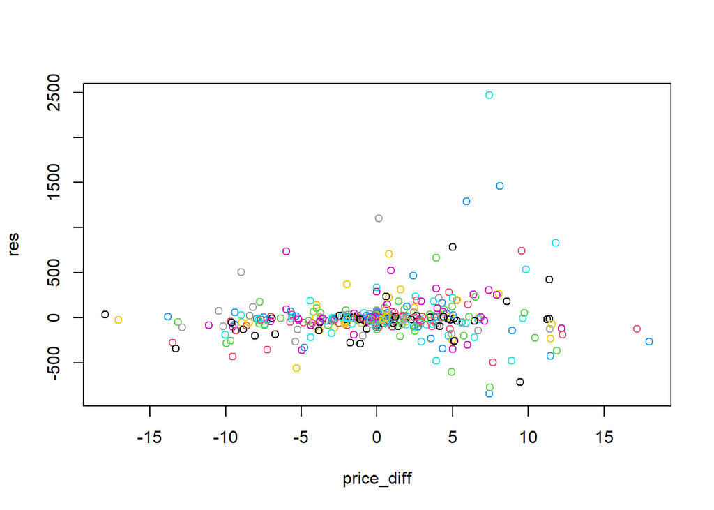

```r
product8_data[, `:=`(price_diff, price - shift(price, 7))]
product8_data[, `:=`(res, c(rep(NA, 7), as.numeric(product8_arima_model$residuals[1:365])))]

plot(product8_data[, list(price_diff, res)], col = day(product8_data$event_date))
```

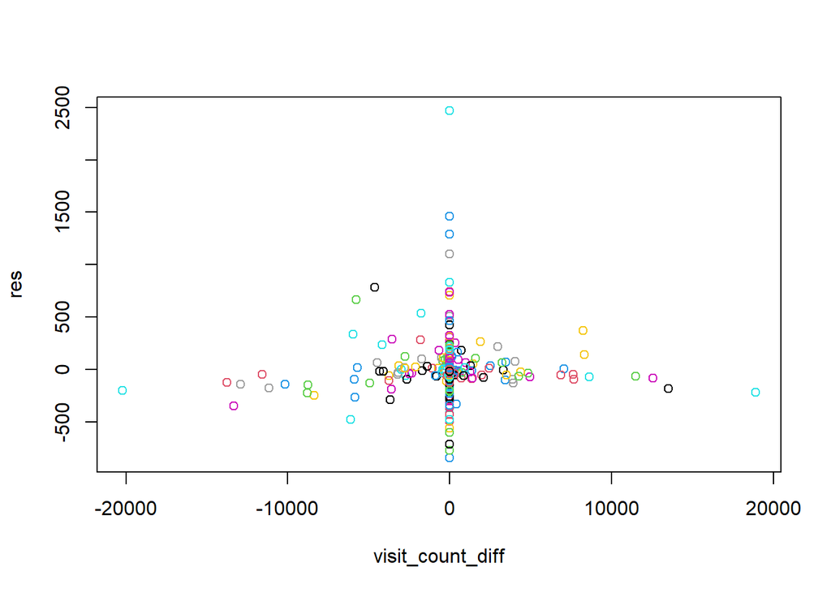

```r
product8_data[, `:=`(visit_count_diff, visit_count - shift(visit_count,
    7))]
plot(product8_data[, list(visit_count_diff, res)], col = day(product8_data$event_date))
```

```r
product8_data$basket_count
```

[output not shown]

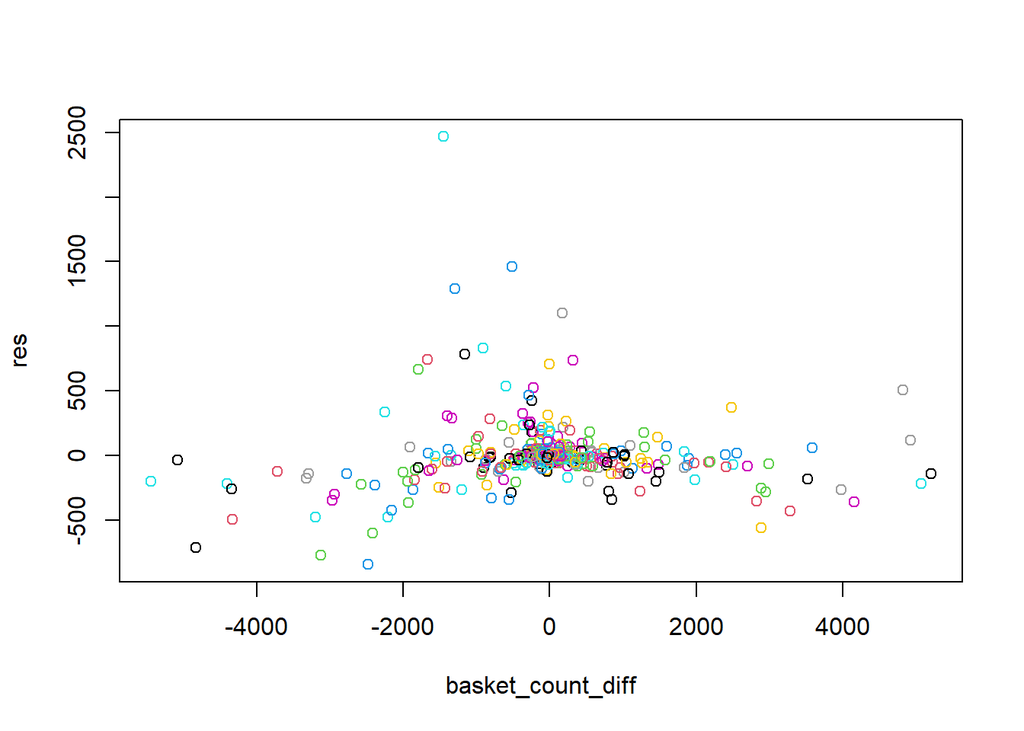

```r
product8_data[, `:=`(basket_count_diff, basket_count - shift(basket_count,
    7))]
plot(product8_data[, list(basket_count_diff, res)], col = day(product8_data$event_date))
```

```r
product8_data$favored_count
```

[output not shown]

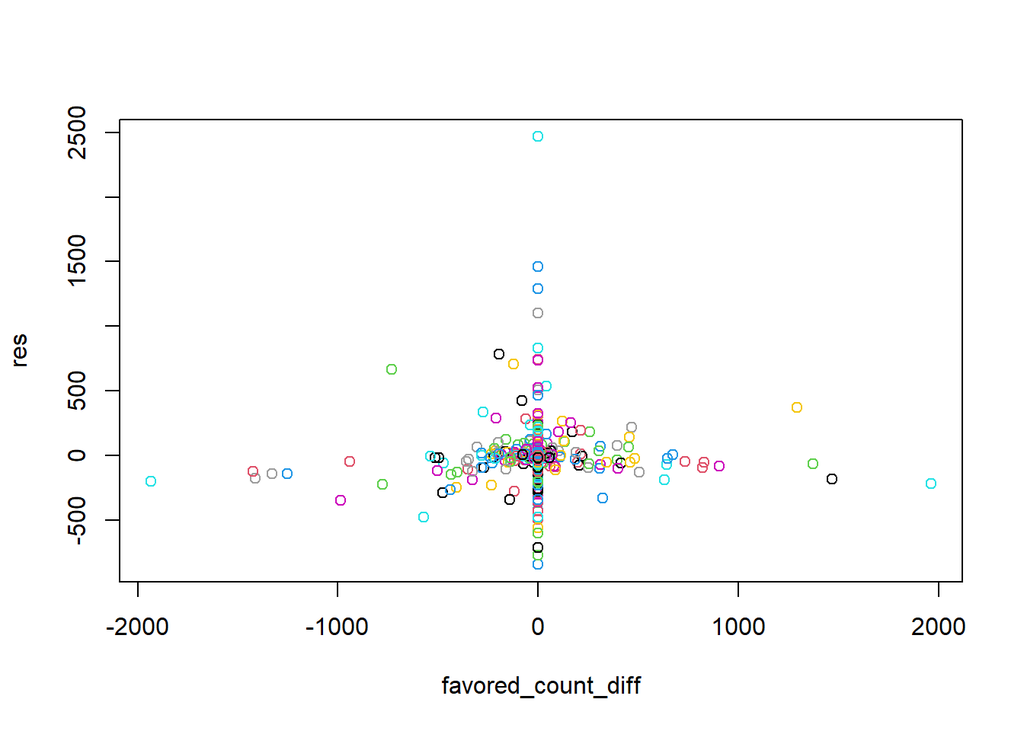

```r
product8_data[, `:=`(favored_count_diff, favored_count - shift(favored_count,
    7))]
plot(product8_data[, list(favored_count_diff, res)], col = day(product8_data$event_date))
```

```r
product8_data$category_sold
```

[output not shown]

[output cut: 16 more lines]

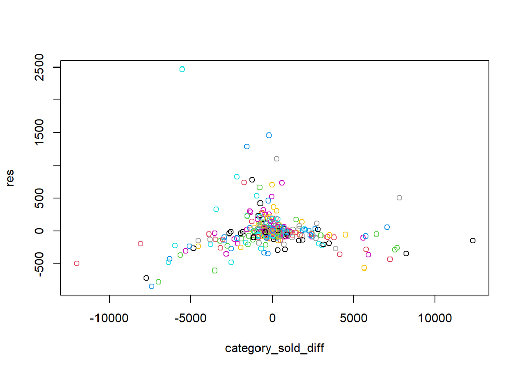

```r
product8_data[, `:=`(category_sold_diff, category_sold - shift(category_sold,
    7))]
plot(product8_data[, list(category_sold_diff, res)], col = day(product8_data$event_date))
```

Category_sold_diff could be added to the ARIMA model.

```r
product8_data[is.na(category_sold_diff) == T, `:=`(category_sold_diff,
    0)]
category_sold_mat_p8 <- matrix(product8_data$category_sold_diff)
arimax_product8 = auto.arima(product7_data$sold_count, xreg = category_sold_mat_p8,
    seasonal = T, trace = T, stepwise = F, approximation = F)
```

```
##
##  ARIMA(0,1,0)                    : 3792.455
##  Regression with ARIMA(0,1,0) errors : 3794.486
##  ARIMA(0,1,1)                    : 3789.502
##  Regression with ARIMA(0,1,1) errors : 3791.542
##  ARIMA(0,1,2)                    : 3785.631
##  Regression with ARIMA(0,1,2) errors : 3787.677
##  ARIMA(0,1,3)                    : 3750.039
##  Regression with ARIMA(0,1,3) errors : 3751.343
##  ARIMA(0,1,4)                    : 3737.334
##  Regression with ARIMA(0,1,4) errors : Inf
##  ARIMA(0,1,5)                    : 3737.849
##  Regression with ARIMA(0,1,5) errors : Inf
##  ARIMA(1,1,0)                    : 3790.03
##  Regression with ARIMA(1,1,0) errors : 3792.071
##  ARIMA(1,1,1)                    : 3741.426
##  Regression with ARIMA(1,1,1) errors : Inf
##  ARIMA(1,1,2)                    : 3742.646
##  Regression with ARIMA(1,1,2) errors : Inf
##  ARIMA(1,1,3)                    : 3736.762
##  Regression with ARIMA(1,1,3) errors : Inf
##  ARIMA(1,1,4)                    : 3737.874
##  Regression with ARIMA(1,1,4) errors : Inf
##  ARIMA(2,1,0)                    : 3791.643
##  Regression with ARIMA(2,1,0) errors : 3793.694
##  ARIMA(2,1,1)                    : 3742.302
##  Regression with ARIMA(2,1,1) errors : Inf
##  ARIMA(2,1,2)                    : 3743.93
##  Regression with ARIMA(2,1,2) errors : Inf
##  ARIMA(2,1,3)                    : 3738.106
##  Regression with ARIMA(2,1,3) errors : Inf
##  ARIMA(3,1,0)                    : 3780.262
##  Regression with ARIMA(3,1,0) errors : 3782.323
##  ARIMA(3,1,1)                    : 3737.265
##  Regression with ARIMA(3,1,1) errors : Inf
##  ARIMA(3,1,2)                    : 3739.262
##  Regression with ARIMA(3,1,2) errors : Inf
##  ARIMA(4,1,0)                    : 3768.255
##  Regression with ARIMA(4,1,0) errors : 3770.326
##  ARIMA(4,1,1)                    : 3739.184
##  Regression with ARIMA(4,1,1) errors : Inf
##  ARIMA(5,1,0)                    : 3764.502
##  Regression with ARIMA(5,1,0) errors : 3766.582
##
##
##
##  Best model: Regression with ARIMA(1,1,3) errors
```

##Product9 ARIMAX

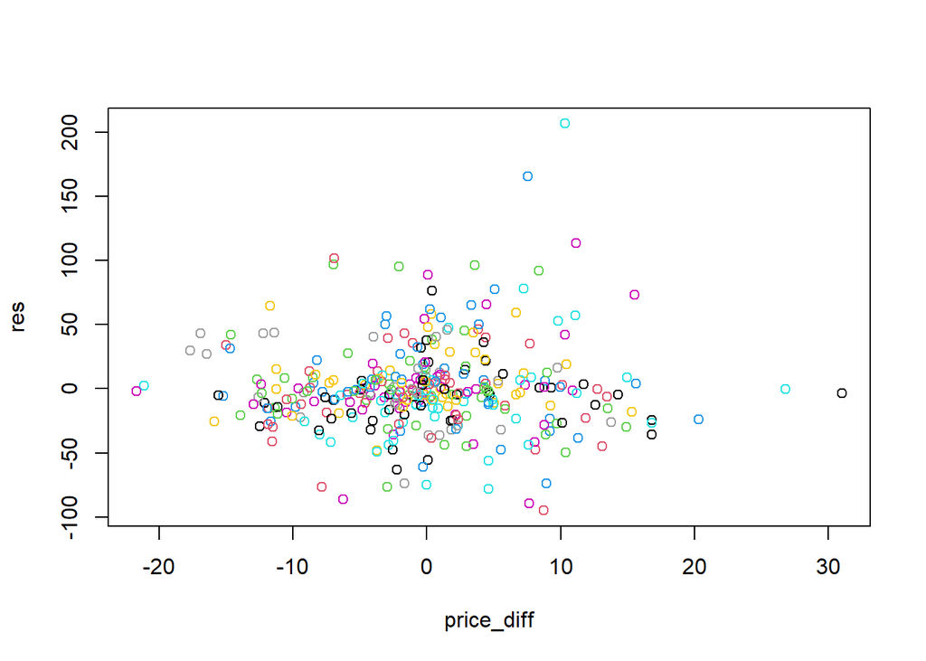

```r
product9_data[, `:=`(price_diff, price - shift(price, 7))]
product9_data[, `:=`(res, c(rep(NA, 7), as.numeric(product9_arima_model$residuals[1:365])))]

plot(product9_data[, list(price_diff, res)], col = day(product9_data$event_date))
```

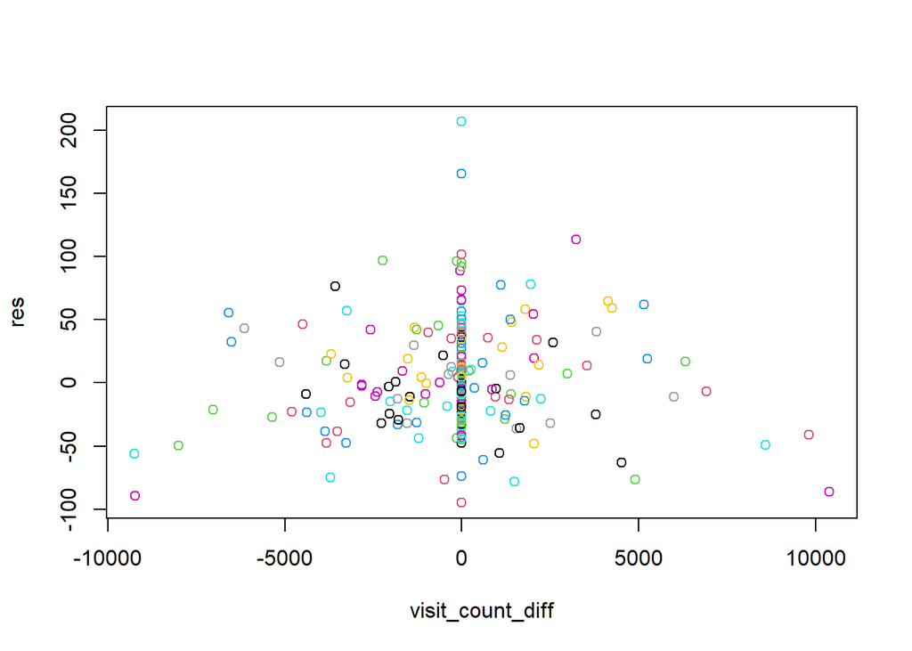

```r
product9_data[, `:=`(visit_count_diff, visit_count - shift(visit_count,
    7))]
plot(product9_data[, list(visit_count_diff, res)], col = day(product9_data$event_date))
```

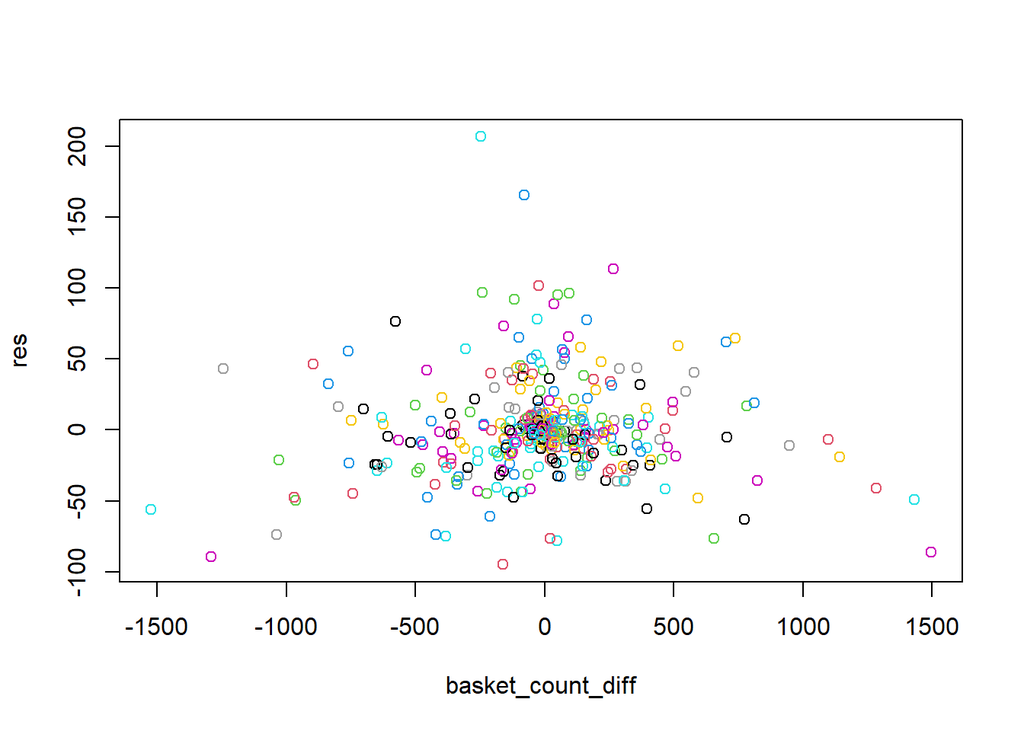

```r
product9_data[, `:=`(basket_count_diff, basket_count - shift(basket_count,
    7))]
plot(product9_data[, list(basket_count_diff, res)], col = day(product9_data$event_date))
```

```r
product9_data$favored_count
```

[output not shown]

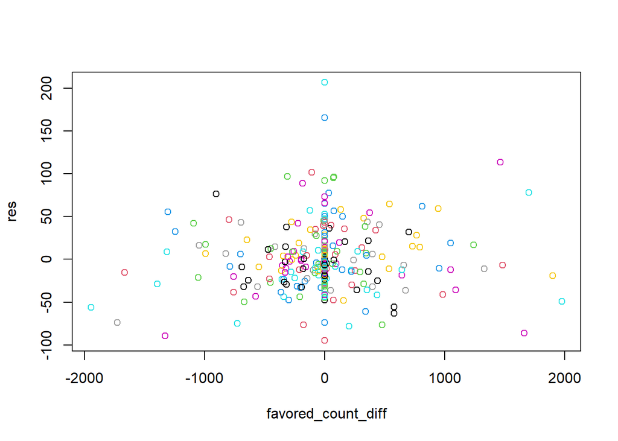

```r
product9_data[, `:=`(favored_count_diff, favored_count - shift(favored_count,
    7))]
plot(product9_data[, list(favored_count_diff, res)], col = day(product9_data$event_date))
```

```r
product9_data$category_sold
```

[output not shown]

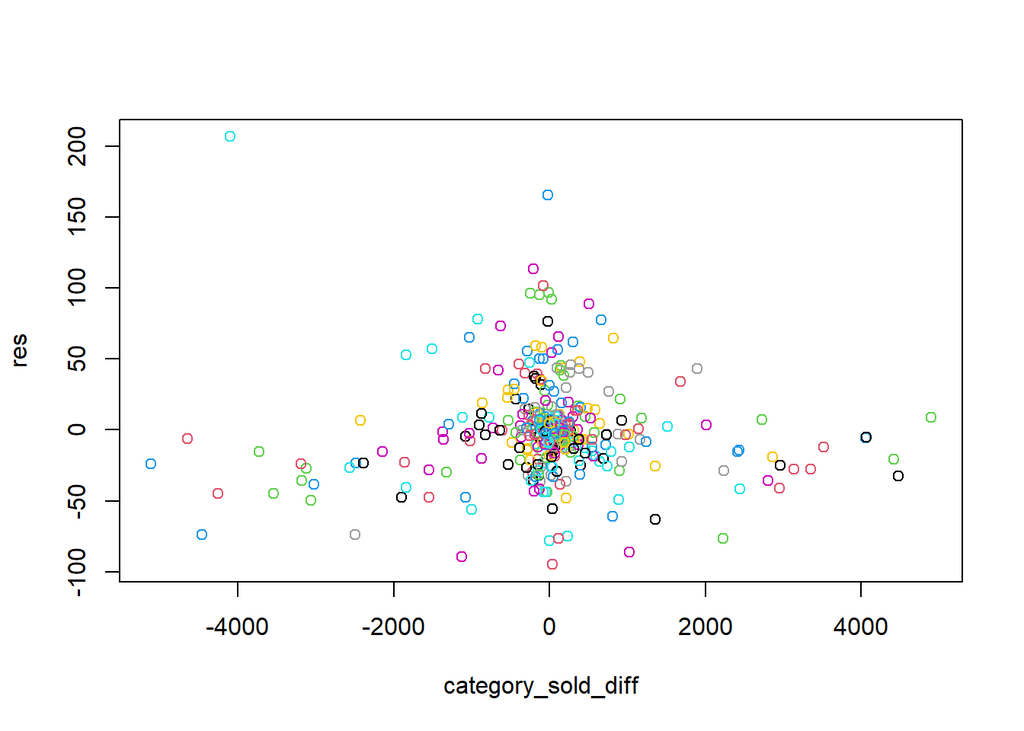

```r
product9_data[, `:=`(category_sold_diff, category_sold - shift(category_sold,
    7))]
plot(product9_data[, list(category_sold_diff, res)], col = day(product9_data$event_date))
```

```r
product9_data$category_brand_sold
```

[output not shown]

[output cut: 16 more lines]

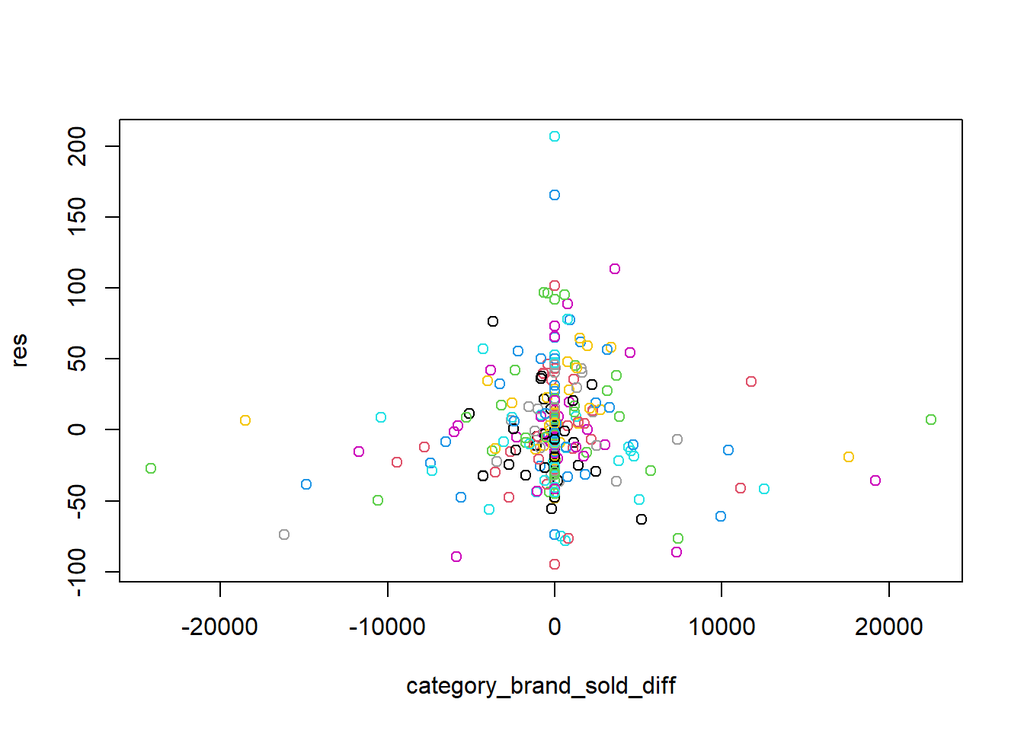

```r
product9_data[, `:=`(category_brand_sold_diff, category_brand_sold -
    shift(category_brand_sold, 7))]
plot(product9_data[, list(category_brand_sold_diff, res)], col = day(product9_data$event_date))
```

We can use price_diff as a possible regressor.

```r
product9_data[is.na(price_diff) == T, `:=`(price_diff, 0)]
price_diff_mat_p9 <- matrix(product9_data$price_diff)
arimax_product9 = auto.arima(product9_data$sold_count, xreg = price_diff_mat_p9,
    seasonal = T, trace = T, stepwise = F, approximation = F)
```

```
##
##  ARIMA(0,1,0)                    : 3860.38
##  Regression with ARIMA(0,1,0) errors : 3862.407
##  ARIMA(0,1,1)                    : 3856.398
##  Regression with ARIMA(0,1,1) errors : 3858.433
##  ARIMA(0,1,2)                    : 3841.621
##  Regression with ARIMA(0,1,2) errors : 3843.648
##  ARIMA(0,1,3)                    : 3837.92
##  Regression with ARIMA(0,1,3) errors : 3839.925
##  ARIMA(0,1,4)                    : 3835.305
##  Regression with ARIMA(0,1,4) errors : 3837.227
##  ARIMA(0,1,5)                    : 3833.391
##  Regression with ARIMA(0,1,5) errors : 3834.468
##  ARIMA(1,1,0)                    : 3858.434
##  Regression with ARIMA(1,1,0) errors : 3860.471
##  ARIMA(1,1,1)                    : 3828.174
##  Regression with ARIMA(1,1,1) errors : 3827.908
##  ARIMA(1,1,2)                    : 3829.703
##  Regression with ARIMA(1,1,2) errors : 3829.588
##  ARIMA(1,1,3)                    : 3831.471
##  Regression with ARIMA(1,1,3) errors : 3831.228
##  ARIMA(1,1,4)                    : 3833.551
##  Regression with ARIMA(1,1,4) errors : 3833.253
##  ARIMA(2,1,0)                    : 3851.833
##  Regression with ARIMA(2,1,0) errors : 3853.879
##  ARIMA(2,1,1)                    : 3829.744
##  Regression with ARIMA(2,1,1) errors : 3829.624
##  ARIMA(2,1,2)                    : 3832.095
##  Regression with ARIMA(2,1,2) errors : 3831.843
##  ARIMA(2,1,3)                    : 3833.378
##  Regression with ARIMA(2,1,3) errors : 3833.317
##  ARIMA(3,1,0)                    : 3850.398
##  Regression with ARIMA(3,1,0) errors : 3852.453
##  ARIMA(3,1,1)                    : 3831.545
##  Regression with ARIMA(3,1,1) errors : 3831.324
##  ARIMA(3,1,2)                    : 3833.47
##  Regression with ARIMA(3,1,2) errors : 3833.396
##  ARIMA(4,1,0)                    : 3843.654
##  Regression with ARIMA(4,1,0) errors : 3845.709
##  ARIMA(4,1,1)                    : 3836.206
##  Regression with ARIMA(4,1,1) errors : 3838.235
##  ARIMA(5,1,0)                    : 3836.589
##  Regression with ARIMA(5,1,0) errors : 3838.636
##
##
##
##  Best model: Regression with ARIMA(1,1,1) errors
```

#Forecast

To compare arima and arimax models, we compare them for test period which is from 2021-05-11 to 2021-05-29.

```r
train_start = as.Date("2020-05-25")
test_start = as.Date("2021-05-11")
test_end = as.Date("2021-05-29")
train_date = seq(train_start, test_start, by = "day")
str(train_date)
```

```
##  Date[1:352], format: "2020-05-25" "2020-05-26" "2020-05-27" "2020-05-28" "2020-05-29" ...
```

```r
test_dates = seq(test_start, test_end, by = "day")
test_dates
```

```
##  [1] "2021-05-11" "2021-05-12" "2021-05-13" "2021-05-14" "2021-05-15"
##  [6] "2021-05-16" "2021-05-17" "2021-05-18" "2021-05-19" "2021-05-20"
## [11] "2021-05-21" "2021-05-22" "2021-05-23" "2021-05-24" "2021-05-25"
## [16] "2021-05-26" "2021-05-27" "2021-05-28" "2021-05-29"
```

##Product 1

We define our functions for arima and arimax models.

```r
# forecast with ARIMA models
forecast_with_arima = function(data, forecast_ahead, target_name = "sold_count",
    is_seasonal = F, is_stepwise = F, is_trace = T, is_approx = F) {
    command_string = sprintf("input_series=data$%s", target_name)
    print(command_string)
    eval(parse(text = command_string))

    fitted = arima(input_series, order = c(0, 0, 1), seasonal = c(0,
        0, 1))

    forecasted = forecast(fitted, h = forecast_ahead)
    return(list(forecast = as.numeric(forecasted$mean), model = fitted))
}
# forecast with ARIMAX models
forecast_with_arimax = function(data, forecast_ahead, target_name = "sold_count",
    is_seasonal = F, is_stepwise = F, is_trace = T, is_approx = F) {
    command_string = sprintf("input_series=data$%s", target_name)
    print(command_string)
    eval(parse(text = command_string))

    fitted = arimax_product1

    # forecasted=forecast(fitted,xreg=price_diff_mat_p1[239],
    # h=nahead)
    forecasted = forecast(fitted, xreg = tail(price_diff_mat_p1[!is.na(price_diff_mat_p1)],
        1), h = nahead)

    return(list(forecast = as.numeric(forecasted$mean), model = fitted))
}
```

```r
# loop over the test dates
forecast_ahead = 1

results = vector("list", length(test_dates))
i = 1
for (i in 1:length(test_dates)) {
    current_date = test_dates[i] - forecast_ahead
    print(test_dates[i])
    past_data = product1_data[event_date <= current_date]
    forecast_data = product1_data[event_date == test_dates[i]]

    arima_forecast = forecast_with_arima(past_data, forecast_ahead,
        "sold_count", is_trace = F)
    forecast_data[, `:=`(arima_prediction, arima_forecast$forecast)]
    arimax_forecast = forecast_with_arimax(past_data, forecast_ahead,
        "sold_count", is_trace = F)
    forecast_data[, `:=`(arimax_prediction, arimax_forecast$forecast)]

    results[[i]] = forecast_data
}
```

```
## [1] "2021-05-11"
## [1] "input_series=data$sold_count"
## [1] "input_series=data$sold_count"
## [1] "2021-05-12"
## [1] "input_series=data$sold_count"
## [1] "input_series=data$sold_count"
## [1] "2021-05-13"
## [1] "input_series=data$sold_count"
## [1] "input_series=data$sold_count"
## [1] "2021-05-14"
## [1] "input_series=data$sold_count"
## [1] "input_series=data$sold_count"
## [1] "2021-05-15"
## [1] "input_series=data$sold_count"
## [1] "input_series=data$sold_count"
```

[output cut: 42 more lines]

```r
overall_results = rbindlist(results)

melted_result = melt(overall_results, c("event_date", "sold_count"),
    c("arima_prediction", "arimax_prediction"))
```

We turned the results into melted results(long form).

```r
melted_result
```

```
##     event_date sold_count          variable        value
##  1: 2021-05-11          3  arima_prediction 5.404704e-01
##  2: 2021-05-12          5  arima_prediction 5.479946e-01
##  3: 2021-05-13          1  arima_prediction 5.559558e-01
##  4: 2021-05-14          1  arima_prediction 5.531254e-01
##  5: 2021-05-15          1  arima_prediction 5.546790e-01
##  6: 2021-05-16          1  arima_prediction 5.548164e-01
##  7: 2021-05-17          3  arima_prediction 5.552911e-01
##  8: 2021-05-18          2  arima_prediction 5.616536e-01
##  9: 2021-05-19          1  arima_prediction 5.621574e-01
## 10: 2021-05-20          0  arima_prediction 5.620824e-01
## 11: 2021-05-21          1  arima_prediction 5.598573e-01
## 12: 2021-05-22          0  arima_prediction 5.612916e-01
## 13: 2021-05-23          0  arima_prediction 5.587257e-01
## 14: 2021-05-24          3  arima_prediction 5.574481e-01
```

[output cut: 25 more lines]

```r
accu = function(actual, forecast) {
    n = length(actual)
    error = actual - forecast
    mean = mean(actual)
    sd = sd(actual)
    CV = sd/mean
    FBias = sum(error)/sum(actual)
    MAPE = sum(abs(error/actual))/n
    RMSE = sqrt(sum(error^2)/n)
    MAD = sum(abs(error))/n
    MADP = sum(abs(error))/sum(abs(actual))
    WMAPE = MAD/mean
    l = data.frame(n, mean, sd, CV, FBias, MAPE, RMSE, MAD, MADP,
        WMAPE)
    return(l)
}
```

To compare models,we accumulate errors of our models in terms of statistical methods with our accumulation function we defined above.

```r
performance = melted_result[, accu(sold_count, value), by = list(variable)]

performance
```

```
##             variable  n     mean       sd        CV     FBias MAPE     RMSE
## 1:  arima_prediction 19 1.736842 1.407997 0.8106651 0.6778688  Inf 1.808265
## 2: arimax_prediction 19 1.736842 1.407997 0.8106651 0.9999991  Inf 2.212404
##         MAD      MADP     WMAPE
## 1: 1.354414 0.7798142 0.7798142
## 2: 1.736841 0.9999994 0.9999994
```

##Product 2

We define our functions for arima and arimax models.

```r
# forecast with ARIMA models
forecast_with_arima = function(data, forecast_ahead, target_name = "sold_count",
    is_seasonal = F, is_stepwise = F, is_trace = T, is_approx = F) {
    command_string = sprintf("input_series=data$%s", target_name)
    print(command_string)
    eval(parse(text = command_string))

    fitted = arima(input_series, order = c(2, 0, 0), seasonal = c(2,
        0, 1))

    forecasted = forecast(fitted, h = forecast_ahead)
    return(list(forecast = as.numeric(forecasted$mean), model = fitted))
}
# forecast with ARIMAX models
forecast_with_arimax = function(data, forecast_ahead, target_name = "sold_count",
    is_seasonal = F, is_stepwise = F, is_trace = T, is_approx = F) {
    command_string = sprintf("input_series=data$%s", target_name)
    print(command_string)
    eval(parse(text = command_string))

    fitted = arimax_product2

    forecasted = forecast(fitted, xreg = tail(visit_count_diff_mat_p2[!is.na(visit_count_diff_mat_p2)],
        1), h = nahead)

    return(list(forecast = as.numeric(forecasted$mean), model = fitted))
}
```

```r
# loop over the test dates
forecast_ahead = 1

results = vector("list", length(test_dates))
i = 1
for (i in 1:length(test_dates)) {
    current_date = test_dates[i] - forecast_ahead
    print(test_dates[i])
    past_data = product2_data[event_date <= current_date]
    forecast_data = product2_data[event_date == test_dates[i]]

    arima_forecast = forecast_with_arima(past_data, forecast_ahead,
        "sold_count", is_trace = F)
    forecast_data[, `:=`(arima_prediction, arima_forecast$forecast)]
    arimax_forecast = forecast_with_arimax(past_data, forecast_ahead,
        "sold_count", is_trace = F)
    forecast_data[, `:=`(arimax_prediction, arimax_forecast$forecast)]

    results[[i]] = forecast_data
}
```

```
## [1] "2021-05-11"
## [1] "input_series=data$sold_count"
## [1] "input_series=data$sold_count"
## [1] "2021-05-12"
## [1] "input_series=data$sold_count"
## [1] "input_series=data$sold_count"
## [1] "2021-05-13"
## [1] "input_series=data$sold_count"
## [1] "input_series=data$sold_count"
## [1] "2021-05-14"
## [1] "input_series=data$sold_count"
## [1] "input_series=data$sold_count"
## [1] "2021-05-15"
## [1] "input_series=data$sold_count"
## [1] "input_series=data$sold_count"
```

[output cut: 42 more lines]

```r
overall_results = rbindlist(results)

melted_result = melt(overall_results, c("event_date", "sold_count"),
    c("arima_prediction", "arimax_prediction"))
```

We turned the results into melted results(long form).

```r
melted_result
```

```
##     event_date sold_count          variable         value
##  1: 2021-05-11        112  arima_prediction  3.976428e-01
##  2: 2021-05-12        202  arima_prediction  4.212251e-01
##  3: 2021-05-13        142  arima_prediction  3.379481e-01
##  4: 2021-05-14        170  arima_prediction  4.359351e-01
##  5: 2021-05-15        242  arima_prediction  4.414281e-01
##  6: 2021-05-16        173  arima_prediction  1.037243e+00
##  7: 2021-05-17        107  arima_prediction  1.323998e-01
##  8: 2021-05-18        133  arima_prediction  5.940787e-01
##  9: 2021-05-19        109  arima_prediction  6.176498e-01
## 10: 2021-05-20        102  arima_prediction  6.170576e-01
## 11: 2021-05-21        101  arima_prediction  6.027053e-01
## 12: 2021-05-22        186  arima_prediction  1.382863e+00
## 13: 2021-05-23        231  arima_prediction  7.417302e-01
## 14: 2021-05-24        181  arima_prediction  6.420707e-01
```

[output cut: 25 more lines]

```r
accu = function(actual, forecast) {
    n = length(actual)
    error = actual - forecast
    mean = mean(actual)
    sd = sd(actual)
    CV = sd/mean
    FBias = sum(error)/sum(actual)
    MAPE = sum(abs(error/actual))/n
    RMSE = sqrt(sum(error^2)/n)
    MAD = sum(abs(error))/n
    MADP = sum(abs(error))/sum(abs(actual))
    WMAPE = MAD/mean
    l = data.frame(n, mean, sd, CV, FBias, MAPE, RMSE, MAD, MADP,
        WMAPE)
    return(l)
}
```

To compare models,we accumulate errors of our models in terms of statistical methods with our accumulation function we defined above.

```r
performance = melted_result[, accu(sold_count, value), by = list(variable)]

performance
```

```
##             variable  n     mean       sd        CV     FBias      MAPE
## 1:  arima_prediction 19 167.1579 46.35762 0.2773284 0.9963769 0.9962351
## 2: arimax_prediction 19 167.1579 46.35762 0.2773284 1.0000000 1.0000000
##        RMSE      MAD      MADP     WMAPE
## 1: 172.5347 166.5523 0.9963769 0.9963769
## 2: 173.1406 167.1579 1.0000000 1.0000000
```

View of data shows that arima prediction is better in terms of MAPE.

#Product 3

We define our functions for arima and arimax models.

```r
# forecast with ARIMA models
forecast_with_arima = function(data, forecast_ahead, target_name = "sold_count",
    is_seasonal = F, is_stepwise = F, is_trace = T, is_approx = F) {
    command_string = sprintf("input_series=data$%s", target_name)
    print(command_string)
    eval(parse(text = command_string))

    fitted = arima(input_series, order = c(2, 0, 0), seasonal = c(2,
        0, 2))

    forecasted = forecast(fitted, h = forecast_ahead)
    return(list(forecast = as.numeric(forecasted$mean), model = fitted))
}
# forecast with ARIMAX models
forecast_with_arimax = function(data, forecast_ahead, target_name = "sold_count",
    is_seasonal = F, is_stepwise = F, is_trace = T, is_approx = F) {
    command_string = sprintf("input_series=data$%s", target_name)
    print(command_string)
    eval(parse(text = command_string))

    fitted = arimax_product3

    forecasted = forecast(fitted, xreg = tail(basket_count_mat_p3[!is.na(basket_count_mat_p3)],
        1), h = nahead)

    return(list(forecast = as.numeric(forecasted$mean), model = fitted))
}
```

```r
# loop over the test dates
forecast_ahead = 1

results = vector("list", length(test_dates))
i = 1
for (i in 1:length(test_dates)) {
    current_date = test_dates[i] - forecast_ahead
    print(test_dates[i])
    past_data = product3_data[event_date <= current_date]
    forecast_data = product3_data[event_date == test_dates[i]]

    arima_forecast = forecast_with_arima(past_data, forecast_ahead,
        "sold_count", is_trace = F)
    forecast_data[, `:=`(arima_prediction, arima_forecast$forecast)]
    arimax_forecast = forecast_with_arimax(past_data, forecast_ahead,
        "sold_count", is_trace = F)
    forecast_data[, `:=`(arimax_prediction, arimax_forecast$forecast)]

    results[[i]] = forecast_data
}
```

```
## [1] "2021-05-11"
## [1] "input_series=data$sold_count"
## [1] "input_series=data$sold_count"
## [1] "2021-05-12"
## [1] "input_series=data$sold_count"
## [1] "input_series=data$sold_count"
## [1] "2021-05-13"
## [1] "input_series=data$sold_count"
## [1] "input_series=data$sold_count"
## [1] "2021-05-14"
## [1] "input_series=data$sold_count"
## [1] "input_series=data$sold_count"
## [1] "2021-05-15"
## [1] "input_series=data$sold_count"
## [1] "input_series=data$sold_count"
```

[output cut: 42 more lines]

```r
overall_results = rbindlist(results)

melted_result = melt(overall_results, c("event_date", "sold_count"),
    c("arima_prediction", "arimax_prediction"))
```

We turned the results into melted results(long form).

```r
melted_result
```

```
##     event_date sold_count          variable    value
##  1: 2021-05-11         35  arima_prediction 37.60139
##  2: 2021-05-12         53  arima_prediction 38.79232
##  3: 2021-05-13         31  arima_prediction 38.02702
##  4: 2021-05-14         59  arima_prediction 38.80118
##  5: 2021-05-15         66  arima_prediction 38.61601
##  6: 2021-05-16         46  arima_prediction 39.42064
##  7: 2021-05-17         24  arima_prediction 37.92912
##  8: 2021-05-18         37  arima_prediction 37.77184
##  9: 2021-05-19         40  arima_prediction 37.76804
## 10: 2021-05-20         37  arima_prediction 37.77880
## 11: 2021-05-21         34  arima_prediction 37.69812
## 12: 2021-05-22         41  arima_prediction 37.68953
## 13: 2021-05-23         45  arima_prediction 37.69094
## 14: 2021-05-24         31  arima_prediction 39.04140
```

[output cut: 25 more lines]

```r
accu = function(actual, forecast) {
    n = length(actual)
    error = actual - forecast
    mean = mean(actual)
    sd = sd(actual)
    CV = sd/mean
    FBias = sum(error)/sum(actual)
    MAPE = sum(abs(error/actual))/n
    RMSE = sqrt(sum(error^2)/n)
    MAD = sum(abs(error))/n
    MADP = sum(abs(error))/sum(abs(actual))
    WMAPE = MAD/mean
    l = data.frame(n, mean, sd, CV, FBias, MAPE, RMSE, MAD, MADP,
        WMAPE)
    return(l)
}
```

To compare models,we accumulate errors of our models in terms of statistical methods with our accumulation function we defined above.

```r
performance = melted_result[, accu(sold_count, value), by = list(variable)]

performance
```

```
##             variable  n     mean       sd        CV      FBias      MAPE
## 1:  arima_prediction 19 42.10526 10.39174 0.2468039 0.09479490 0.1789073
## 2: arimax_prediction 19 42.10526 10.39174 0.2468039 0.06871078 0.1790068
##        RMSE      MAD      MADP     WMAPE
## 1: 10.74019 7.873866 0.1870043 0.1870043
## 2: 10.52020 7.703340 0.1829543 0.1829543
```

View of data shows that arima prediction is better in terms of MAPE.

#Product 4

We define our functions for arima and arimax models.

```r
# forecast with ARIMA models
forecast_with_arima = function(data, forecast_ahead, target_name = "sold_count",
    is_seasonal = F, is_stepwise = F, is_trace = T, is_approx = F) {
    command_string = sprintf("input_series=data$%s", target_name)
    print(command_string)
    eval(parse(text = command_string))

    fitted = arima(input_series, order = c(1, 0, 2), seasonal = c(0,
        0, 1))

    forecasted = forecast(fitted, h = forecast_ahead)
    return(list(forecast = as.numeric(forecasted$mean), model = fitted))
}
# forecast with ARIMAX models
forecast_with_arimax = function(data, forecast_ahead, target_name = "sold_count",
    is_seasonal = F, is_stepwise = F, is_trace = T, is_approx = F) {
    command_string = sprintf("input_series=data$%s", target_name)
    print(command_string)
    eval(parse(text = command_string))

    fitted = arimax_product4

    forecasted = forecast(fitted, xreg = tail(category_sold_diff_mat_p4[!is.na(category_sold_diff_mat_p4)],
        1), h = nahead)

    return(list(forecast = as.numeric(forecasted$mean), model = fitted))
}
```

```r
# loop over the test dates
forecast_ahead = 1

results = vector("list", length(test_dates))
i = 1
for (i in 1:length(test_dates)) {
    current_date = test_dates[i] - forecast_ahead
    print(test_dates[i])
    past_data = product4_data[event_date <= current_date]
    forecast_data = product4_data[event_date == test_dates[i]]

    arima_forecast = forecast_with_arima(past_data, forecast_ahead,
        "sold_count", is_trace = F)
    forecast_data[, `:=`(arima_prediction, arima_forecast$forecast)]
    arimax_forecast = forecast_with_arimax(past_data, forecast_ahead,
        "sold_count", is_trace = F)
    forecast_data[, `:=`(arimax_prediction, arimax_forecast$forecast)]

    results[[i]] = forecast_data
}
```

```
## [1] "2021-05-11"
## [1] "input_series=data$sold_count"
## [1] "input_series=data$sold_count"
## [1] "2021-05-12"
## [1] "input_series=data$sold_count"
## [1] "input_series=data$sold_count"
## [1] "2021-05-13"
## [1] "input_series=data$sold_count"
## [1] "input_series=data$sold_count"
## [1] "2021-05-14"
## [1] "input_series=data$sold_count"
## [1] "input_series=data$sold_count"
## [1] "2021-05-15"
## [1] "input_series=data$sold_count"
## [1] "input_series=data$sold_count"
```

[output cut: 42 more lines]

```r
overall_results = rbindlist(results)

melted_result = melt(overall_results, c("event_date", "sold_count"),
    c("arima_prediction", "arimax_prediction"))
```

We turned the results into melted results(long form).

```r
melted_result
```

```
##     event_date sold_count          variable    value
##  1: 2021-05-11        363  arima_prediction 939.5411
##  2: 2021-05-12        522  arima_prediction 939.2181
##  3: 2021-05-13        560  arima_prediction 938.9446
##  4: 2021-05-14        512  arima_prediction 938.4145
##  5: 2021-05-15        550  arima_prediction 938.4417
##  6: 2021-05-16        530  arima_prediction 937.9748
##  7: 2021-05-17        293  arima_prediction 937.5866
##  8: 2021-05-18        301  arima_prediction 937.3904
##  9: 2021-05-19        273  arima_prediction 936.6304
## 10: 2021-05-20        255  arima_prediction 936.0824
## 11: 2021-05-21        229  arima_prediction 935.6306
## 12: 2021-05-22        261  arima_prediction 935.0349
## 13: 2021-05-23        284  arima_prediction 934.4551
## 14: 2021-05-24        240  arima_prediction 934.0283
```

[output cut: 25 more lines]

```r
accu = function(actual, forecast) {
    n = length(actual)
    error = actual - forecast
    mean = mean(actual)
    sd = sd(actual)
    CV = sd/mean
    FBias = sum(error)/sum(actual)
    MAPE = sum(abs(error/actual))/n
    RMSE = sqrt(sum(error^2)/n)
    MAD = sum(abs(error))/n
    MADP = sum(abs(error))/sum(abs(actual))
    WMAPE = MAD/mean
    l = data.frame(n, mean, sd, CV, FBias, MAPE, RMSE, MAD, MADP,
        WMAPE)
    return(l)
}
```

To compare models,we accumulate errors of our models in terms of statistical methods with our accumulation function we defined above.

```r
performance = melted_result[, accu(sold_count, value), by = list(variable)]

performance
```

```
##             variable  n     mean       sd        CV      FBias      MAPE
## 1:  arima_prediction 19 340.1053 124.5498 0.3662096 -1.7517350 2.0559821
## 2: arimax_prediction 19 340.1053 124.5498 0.3662096 -0.2099844 0.4654088
##        RMSE      MAD      MADP     WMAPE
## 1: 607.6258 595.7743 1.7517350 1.7517350
## 2: 140.7002 136.2999 0.4007581 0.4007581
```

View of data shows that arimax prediction is better in terms of MAPE.

#Product 5

We define our functions for arima and arimax models.

```r
product5_arima_model
```

```
## Series: product5_dec_daily$random
## ARIMA(1,0,1)(1,0,1)[7] with zero mean
##
## Coefficients:
##           ar1     ma1     sar1    sma1
##       -0.0229  0.2056  -0.1856  0.2837
## s.e.   0.0530  0.0491   0.1669  0.1632
##
## sigma^2 estimated as 15049:  log likelihood=-16142.25
## AIC=32294.49   AICc=32294.52   BIC=32323.79
```

```r
arimax_product5
```

```
## Series: product5_data$sold_count
## Regression with ARIMA(5,0,0) errors
##
## Coefficients:
##          ar1      ar2     ar3      ar4     ar5  intercept    xreg
##       1.6023  -1.2325  0.7710  -0.4495  0.1912   393.3038  0.6316
## s.e.  0.0510   0.0952  0.1075   0.0948  0.0509    26.6493  0.0081
##
## sigma^2 estimated as 3821:  log likelihood=-2059.88
## AIC=4135.75   AICc=4136.15   BIC=4167.1
```

```r
# forecast with ARIMA models
forecast_with_arima = function(data, forecast_ahead, target_name = "sold_count",
    is_seasonal = F, is_stepwise = F, is_trace = T, is_approx = F) {
    command_string = sprintf("input_series=data$%s", target_name)
    print(command_string)
    eval(parse(text = command_string))

    fitted = arima(input_series, order = c(1, 0, 1), seasonal = c(1,
        0, 1))

    forecasted = forecast(fitted, h = forecast_ahead)
    return(list(forecast = as.numeric(forecasted$mean), model = fitted))
}
# forecast with ARIMAX models
forecast_with_arimax = function(data, forecast_ahead, target_name = "sold_count",
    is_seasonal = F, is_stepwise = F, is_trace = T, is_approx = F) {
    command_string = sprintf("input_series=data$%s", target_name)
    print(command_string)
    eval(parse(text = command_string))

    fitted = arimax_product5

    forecasted = forecast(fitted, xreg = tail(residuals_mat_p5[!is.na(residuals_mat_p5)],
        1), h = nahead)

    return(list(forecast = as.numeric(forecasted$mean), model = fitted))
}
```

```r
# loop over the test dates
forecast_ahead = 1

results = vector("list", length(test_dates))
i = 1
for (i in 1:length(test_dates)) {
    current_date = test_dates[i] - forecast_ahead
    print(test_dates[i])
    past_data = product5_data[event_date <= current_date]
    forecast_data = product5_data[event_date == test_dates[i]]

    arima_forecast = forecast_with_arima(past_data, forecast_ahead,
        "sold_count", is_trace = F)
    forecast_data[, `:=`(arima_prediction, arima_forecast$forecast)]
    arimax_forecast = forecast_with_arimax(past_data, forecast_ahead,
        "sold_count", is_trace = F)
    forecast_data[, `:=`(arimax_prediction, arimax_forecast$forecast)]

    results[[i]] = forecast_data
}
```

```
## [1] "2021-05-11"
## [1] "input_series=data$sold_count"
## [1] "input_series=data$sold_count"
## [1] "2021-05-12"
## [1] "input_series=data$sold_count"
## [1] "input_series=data$sold_count"
## [1] "2021-05-13"
## [1] "input_series=data$sold_count"
## [1] "input_series=data$sold_count"
## [1] "2021-05-14"
## [1] "input_series=data$sold_count"
## [1] "input_series=data$sold_count"
## [1] "2021-05-15"
## [1] "input_series=data$sold_count"
## [1] "input_series=data$sold_count"
```

[output cut: 42 more lines]

```r
overall_results = rbindlist(results)

melted_result = melt(overall_results, c("event_date", "sold_count"),
    c("arima_prediction", "arimax_prediction"))
```

We turned the results into melted results(long form).

```r
melted_result
```

```
##     event_date sold_count          variable    value
##  1: 2021-05-11        149  arima_prediction 509.9902
##  2: 2021-05-12        389  arima_prediction 506.8503
##  3: 2021-05-13        511  arima_prediction 508.3720
##  4: 2021-05-14        610  arima_prediction 507.9804
##  5: 2021-05-15        473  arima_prediction 507.9171
##  6: 2021-05-16        496  arima_prediction 507.7354
##  7: 2021-05-17        440  arima_prediction 507.9670
##  8: 2021-05-18        371  arima_prediction 507.8527
##  9: 2021-05-19        303  arima_prediction 507.4218
## 10: 2021-05-20        396  arima_prediction 507.2979
## 11: 2021-05-21        178  arima_prediction 507.4749
## 12: 2021-05-22        535  arima_prediction 507.3865
## 13: 2021-05-23        562  arima_prediction 508.6232
## 14: 2021-05-24        384  arima_prediction 508.3583
```

[output cut: 25 more lines]

```r
accu = function(actual, forecast) {
    n = length(actual)
    error = actual - forecast
    mean = mean(actual)
    sd = sd(actual)
    CV = sd/mean
    FBias = sum(error)/sum(actual)
    MAPE = sum(abs(error/actual))/n
    RMSE = sqrt(sum(error^2)/n)
    MAD = sum(abs(error))/n
    MADP = sum(abs(error))/sum(abs(actual))
    WMAPE = MAD/mean
    l = data.frame(n, mean, sd, CV, FBias, MAPE, RMSE, MAD, MADP,
        WMAPE)
    return(l)
}
```

To compare models,we accumulate errors of our models in terms of statistical methods with our accumulation function we defined above.

```r
performance = melted_result[, accu(sold_count, value), by = list(variable)]

performance
```

```
##             variable  n     mean       sd        CV      FBias      MAPE
## 1:  arima_prediction 19 374.8421 133.5021 0.3561555 -0.3544551 0.6006880
## 2: arimax_prediction 19 374.8421 133.5021 0.3561555 -0.1674650 0.4587804
##        RMSE      MAD      MADP     WMAPE
## 1: 185.7820 152.4055 0.4065859 0.4065859
## 2: 144.3094 122.1092 0.3257618 0.3257618
```

We define our functions for arima and arimax models.

```r
# forecast with ARIMA models
forecast_with_arima = function(data, forecast_ahead, target_name = "sold_count",
    is_seasonal = F, is_stepwise = F, is_trace = T, is_approx = F) {
    command_string = sprintf("input_series=data$%s", target_name)
    print(command_string)
    eval(parse(text = command_string))

    fitted = arima(input_series, order = c(1, 0, 2), seasonal = c(1,
        0, 1))

    forecasted = forecast(fitted, h = forecast_ahead)
    return(list(forecast = as.numeric(forecasted$mean), model = fitted))
}
# forecast with ARIMAX models
forecast_with_arimax = function(data, forecast_ahead, target_name = "sold_count",
    is_seasonal = F, is_stepwise = F, is_trace = T, is_approx = F) {
    command_string = sprintf("input_series=data$%s", target_name)
    print(command_string)
    eval(parse(text = command_string))

    fitted = arimax_product6

    forecasted = forecast(fitted, xreg = tail(basket_count_diff_mat_p6[!is.na(basket_count_diff_mat_p6)],
        1), h = nahead)

    return(list(forecast = as.numeric(forecasted$mean), model = fitted))
}
```

```r
# loop over the test dates
forecast_ahead = 1

results = vector("list", length(test_dates))
i = 1
for (i in 1:length(test_dates)) {
    current_date = test_dates[i] - forecast_ahead
    print(test_dates[i])
    past_data = product7_data[event_date <= current_date]
    forecast_data = product7_data[event_date == test_dates[i]]

    arima_forecast = forecast_with_arima(past_data, forecast_ahead,
        "sold_count", is_trace = F)
    forecast_data[, `:=`(arima_prediction, arima_forecast$forecast)]
    arimax_forecast = forecast_with_arimax(past_data, forecast_ahead,
        "sold_count", is_trace = F)
    forecast_data[, `:=`(arimax_prediction, arimax_forecast$forecast)]

    results[[i]] = forecast_data
}
```

```
## [1] "2021-05-11"
## [1] "input_series=data$sold_count"
## [1] "input_series=data$sold_count"
## [1] "2021-05-12"
## [1] "input_series=data$sold_count"
## [1] "input_series=data$sold_count"
## [1] "2021-05-13"
## [1] "input_series=data$sold_count"
## [1] "input_series=data$sold_count"
## [1] "2021-05-14"
## [1] "input_series=data$sold_count"
## [1] "input_series=data$sold_count"
## [1] "2021-05-15"
## [1] "input_series=data$sold_count"
## [1] "input_series=data$sold_count"
```

[output cut: 42 more lines]

```r
overall_results = rbindlist(results)

melted_result = melt(overall_results, c("event_date", "sold_count"),
    c("arima_prediction", "arimax_prediction"))
```

We turned the results into melted results(long form).

```r
melted_result
```

```
##     event_date sold_count          variable    value
##  1: 2021-05-11        126  arima_prediction 49.75387
##  2: 2021-05-12        134  arima_prediction 49.75066
##  3: 2021-05-13        170  arima_prediction 49.82353
##  4: 2021-05-14        178  arima_prediction 49.88569
##  5: 2021-05-15        222  arima_prediction 49.85985
##  6: 2021-05-16         98  arima_prediction 50.05962
##  7: 2021-05-17         72  arima_prediction 50.04828
##  8: 2021-05-18         94  arima_prediction 50.00268
##  9: 2021-05-19         85  arima_prediction 50.03672
## 10: 2021-05-20         77  arima_prediction 50.04390
## 11: 2021-05-21         95  arima_prediction 49.87351
## 12: 2021-05-22        104  arima_prediction 49.92735
## 13: 2021-05-23        114  arima_prediction 49.88775
## 14: 2021-05-24        146  arima_prediction 49.91781
```

[output cut: 25 more lines]

```r
accu = function(actual, forecast) {
    n = length(actual)
    error = actual - forecast
    mean = mean(actual)
    sd = sd(actual)
    CV = sd/mean
    FBias = sum(error)/sum(actual)
    MAPE = sum(abs(error/actual))/n
    RMSE = sqrt(sum(error^2)/n)
    MAD = sum(abs(error))/n
    MADP = sum(abs(error))/sum(abs(actual))
    WMAPE = MAD/mean
    l = data.frame(n, mean, sd, CV, FBias, MAPE, RMSE, MAD, MADP,
        WMAPE)
    return(l)
}
```

To compare models,we accumulate errors of our models in terms of statistical methods with our accumulation function we defined above.

```r
performance = melted_result[, accu(sold_count, value), by = list(variable)]

performance
```

```
##             variable  n     mean       sd        CV     FBias      MAPE
## 1:  arima_prediction 19 111.3158 43.64128 0.3920493 0.5511749 0.4878333
## 2: arimax_prediction 19 111.3158 43.64128 0.3920493 0.6321944 0.5805426
##        RMSE      MAD      MADP     WMAPE
## 1: 74.66883 61.35447 0.5511749 0.5511749
## 2: 82.19921 70.37321 0.6321944 0.6321944
```

View of data shows that arima prediction is better in terms of MAPE.

#Product 7

We define our functions for arima and arimax models.

```r
product7_arima_model
```

```
## Series: product7_dec_daily$random
## ARIMA(1,0,2)(2,0,1)[7] with zero mean
##
## Coefficients:
##           ar1     ma1     ma2     sar1     sar2    sma1
##       -0.5086  0.8848  0.3308  -0.4717  -0.0636  0.5021
## s.e.   0.1020  0.0937  0.0239   0.1614   0.0238  0.1614
##
## sigma^2 estimated as 1046:  log likelihood=-12685.84
## AIC=25385.69   AICc=25385.73   BIC=25426.71
```

```r
arimax_product7
```

```
## Series: product7_data$sold_count
## Regression with ARIMA(3,0,2) errors
##
## Coefficients:
##          ar1      ar2     ar3      ma1     ma2  intercept    xreg
##       0.9463  -0.7317  0.3664  -0.1640  0.7235    53.9890  0.0140
## s.e.  0.1536   0.2444  0.1359   0.1338  0.1285     8.3913  0.0028
##
## sigma^2 estimated as 1515:  log likelihood=-1886.99
## AIC=3789.98   AICc=3790.37   BIC=3821.33
```

```r
# forecast with ARIMA models
forecast_with_arima = function(data, forecast_ahead, target_name = "sold_count",
    is_seasonal = F, is_stepwise = F, is_trace = T, is_approx = F) {
    command_string = sprintf("input_series=data$%s", target_name)
    print(command_string)
    eval(parse(text = command_string))

    fitted = arima(input_series, order = c(1, 0, 2), seasonal = c(2,
        0, 1))

    forecasted = forecast(fitted, h = forecast_ahead)
    return(list(forecast = as.numeric(forecasted$mean), model = fitted))
}
# forecast with ARIMAX models
forecast_with_arimax = function(data, forecast_ahead, target_name = "sold_count",
    is_seasonal = F, is_stepwise = F, is_trace = T, is_approx = F) {
    command_string = sprintf("input_series=data$%s", target_name)
    print(command_string)
    eval(parse(text = command_string))

    fitted = arimax_product7

    forecasted = forecast(fitted, xreg = tail(visit_count_mat_p7[!is.na(visit_count_mat_p7)],
        1), h = nahead)

    return(list(forecast = as.numeric(forecasted$mean), model = fitted))
}
```

```r
# loop over the test dates
forecast_ahead = 1

results = vector("list", length(test_dates))
i = 1
for (i in 1:length(test_dates)) {
    current_date = test_dates[i] - forecast_ahead
    print(test_dates[i])
    past_data = product7_data[event_date <= current_date]
    forecast_data = product7_data[event_date == test_dates[i]]

    arima_forecast = forecast_with_arima(past_data, forecast_ahead,
        "sold_count", is_trace = F)
    forecast_data[, `:=`(arima_prediction, arima_forecast$forecast)]
    arimax_forecast = forecast_with_arimax(past_data, forecast_ahead,
        "sold_count", is_trace = F)
    forecast_data[, `:=`(arimax_prediction, arimax_forecast$forecast)]

    results[[i]] = forecast_data
}
```

```
## [1] "2021-05-11"
## [1] "input_series=data$sold_count"
## [1] "input_series=data$sold_count"
## [1] "2021-05-12"
## [1] "input_series=data$sold_count"
## [1] "input_series=data$sold_count"
## [1] "2021-05-13"
## [1] "input_series=data$sold_count"
## [1] "input_series=data$sold_count"
## [1] "2021-05-14"
## [1] "input_series=data$sold_count"
## [1] "input_series=data$sold_count"
## [1] "2021-05-15"
## [1] "input_series=data$sold_count"
## [1] "input_series=data$sold_count"
```

[output cut: 42 more lines]

```r
overall_results = rbindlist(results)

melted_result = melt(overall_results, c("event_date", "sold_count"),
    c("arima_prediction", "arimax_prediction"))
```

We turned the results into melted results(long form).

```r
melted_result
```

```
##     event_date sold_count          variable    value
##  1: 2021-05-11        126  arima_prediction 50.35676
##  2: 2021-05-12        134  arima_prediction 50.30671
##  3: 2021-05-13        170  arima_prediction 50.37569
##  4: 2021-05-14        178  arima_prediction 50.46844
##  5: 2021-05-15        222  arima_prediction 49.54439
##  6: 2021-05-16         98  arima_prediction 49.68743
##  7: 2021-05-17         72  arima_prediction 49.69112
##  8: 2021-05-18         94  arima_prediction 50.58876
##  9: 2021-05-19         85  arima_prediction 50.57940
## 10: 2021-05-20         77  arima_prediction 49.63221
## 11: 2021-05-21         95  arima_prediction 49.48800
## 12: 2021-05-22        104  arima_prediction 49.57158
## 13: 2021-05-23        114  arima_prediction 49.52115
## 14: 2021-05-24        146  arima_prediction 49.54223
```

[output cut: 25 more lines]

```r
accu = function(actual, forecast) {
    n = length(actual)
    error = actual - forecast
    mean = mean(actual)
    sd = sd(actual)
    CV = sd/mean
    FBias = sum(error)/sum(actual)
    MAPE = sum(abs(error/actual))/n
    RMSE = sqrt(sum(error^2)/n)
    MAD = sum(abs(error))/n
    MADP = sum(abs(error))/sum(abs(actual))
    WMAPE = MAD/mean
    l = data.frame(n, mean, sd, CV, FBias, MAPE, RMSE, MAD, MADP,
        WMAPE)
    return(l)
}
```

To compare models,we accumulate errors of our models in terms of statistical methods with our accumulation function we defined above.

```r
performance = melted_result[, accu(sold_count, value), by = list(variable)]

performance
```

```
##             variable  n     mean       sd        CV     FBias      MAPE    RMSE
## 1:  arima_prediction 19 111.3158 43.64128 0.3920493 0.5519702 0.4894221 74.6514
## 2: arimax_prediction 19 111.3158 43.64128 0.3920493 0.5941711 0.5371797 78.6060
##         MAD      MADP     WMAPE
## 1: 61.44300 0.5519702 0.5519702
## 2: 66.14063 0.5941711 0.5941711
```

View of data shows that arima prediction is better in terms of MAPE.

#Product 8

We define our functions for arima and arimax models.

```r
# forecast with ARIMA models
forecast_with_arima = function(data, forecast_ahead, target_name = "sold_count",
    is_seasonal = F, is_stepwise = F, is_trace = T, is_approx = F) {
    command_string = sprintf("input_series=data$%s", target_name)
    print(command_string)
    eval(parse(text = command_string))

    fitted = arima(input_series, order = c(0, 0, 1), seasonal = c(0,
        0, 1))

    forecasted = forecast(fitted, h = forecast_ahead)
    return(list(forecast = as.numeric(forecasted$mean), model = fitted))
}
# forecast with ARIMAX models
forecast_with_arimax = function(data, forecast_ahead, target_name = "sold_count",
    is_seasonal = F, is_stepwise = F, is_trace = T, is_approx = F) {
    command_string = sprintf("input_series=data$%s", target_name)
    print(command_string)
    eval(parse(text = command_string))

    fitted = arimax_product8

    forecasted = forecast(fitted, xreg = tail(category_sold_mat_p8[!is.na(category_sold_mat_p8)],
        1), h = nahead)

    return(list(forecast = as.numeric(forecasted$mean), model = fitted))
}
```

```r
# loop over the test dates
forecast_ahead = 1

results = vector("list", length(test_dates))
i = 1
for (i in 1:length(test_dates)) {
    current_date = test_dates[i] - forecast_ahead
    print(test_dates[i])
    past_data = product8_data[event_date <= current_date]
    forecast_data = product8_data[event_date == test_dates[i]]

    arima_forecast = forecast_with_arima(past_data, forecast_ahead,
        "sold_count", is_trace = F)
    forecast_data[, `:=`(arima_prediction, arima_forecast$forecast)]
    arimax_forecast = forecast_with_arimax(past_data, forecast_ahead,
        "sold_count", is_trace = F)
    forecast_data[, `:=`(arimax_prediction, arimax_forecast$forecast)]

    results[[i]] = forecast_data
}
```

```
## [1] "2021-05-11"
## [1] "input_series=data$sold_count"
## [1] "input_series=data$sold_count"
## [1] "2021-05-12"
## [1] "input_series=data$sold_count"
## [1] "input_series=data$sold_count"
## [1] "2021-05-13"
## [1] "input_series=data$sold_count"
## [1] "input_series=data$sold_count"
## [1] "2021-05-14"
## [1] "input_series=data$sold_count"
## [1] "input_series=data$sold_count"
## [1] "2021-05-15"
## [1] "input_series=data$sold_count"
## [1] "input_series=data$sold_count"
```

[output cut: 42 more lines]

```r
overall_results = rbindlist(results)

melted_result = melt(overall_results, c("event_date", "sold_count"),
    c("arima_prediction", "arimax_prediction"))
```

We turned the results into melted results(long form).

```r
melted_result
```

```
##     event_date sold_count          variable     value
##  1: 2021-05-11        204  arima_prediction 273.36571
##  2: 2021-05-12        263  arima_prediction 272.91825
##  3: 2021-05-13         88  arima_prediction 272.91297
##  4: 2021-05-14        128  arima_prediction 272.01190
##  5: 2021-05-15        144  arima_prediction 271.90366
##  6: 2021-05-16        198  arima_prediction 271.44876
##  7: 2021-05-17        940  arima_prediction 271.28317
##  8: 2021-05-18        854  arima_prediction 273.06861
##  9: 2021-05-19        611  arima_prediction 273.34389
## 10: 2021-05-20        768  arima_prediction 273.65636
## 11: 2021-05-21        581  arima_prediction 274.35769
## 12: 2021-05-22        606  arima_prediction 274.39089
## 13: 2021-05-23        727  arima_prediction 275.08719
## 14: 2021-05-24        632  arima_prediction 275.43295
```

[output cut: 25 more lines]

```r
accu = function(actual, forecast) {
    n = length(actual)
    error = actual - forecast
    mean = mean(actual)
    sd = sd(actual)
    CV = sd/mean
    FBias = sum(error)/sum(actual)
    MAPE = sum(abs(error/actual))/n
    RMSE = sqrt(sum(error^2)/n)
    MAD = sum(abs(error))/n
    MADP = sum(abs(error))/sum(abs(actual))
    WMAPE = MAD/mean
    l = data.frame(n, mean, sd, CV, FBias, MAPE, RMSE, MAD, MADP,
        WMAPE)
    return(l)
}
```

To compare models,we accumulate errors of our models in terms of statistical methods with our accumulation function we defined above.

```r
performance = melted_result[, accu(sold_count, value), by = list(variable)]

performance
```

```
##             variable  n     mean       sd        CV     FBias      MAPE
## 1:  arima_prediction 19 502.8947 256.2574 0.5095648 0.4550669 0.6447023
## 2: arimax_prediction 19 502.8947 256.2574 0.5095648 0.9255869 0.8812548
##        RMSE      MAD      MADP     WMAPE
## 1: 338.0950 293.0151 0.5826569 0.5826569
## 2: 528.0877 465.4728 0.9255869 0.9255869
```

View of data shows that arima prediction is better in terms of MAPE.

#Product 9

We define our functions for arima and arimax models.

```r
product9_arima_model
```

```
## Series: product9_dec_daily$random
## ARIMA(1,0,1)(1,0,1)[7] with zero mean
##
## Coefficients:
##           ar1     ma1     sar1    sma1
##       -0.0651  0.4105  -0.0801  0.2063
## s.e.   0.0385  0.0325   0.1519  0.1494
##
## sigma^2 estimated as 1137:  log likelihood=-12795.32
## AIC=25600.64   AICc=25600.66   BIC=25629.94
```

```r
# forecast with ARIMA models
forecast_with_arima = function(data, forecast_ahead, target_name = "sold_count",
    is_seasonal = F, is_stepwise = F, is_trace = T, is_approx = F) {
    command_string = sprintf("input_series=data$%s", target_name)
    print(command_string)
    eval(parse(text = command_string))

    fitted = arima(input_series, order = c(1, 0, 1), seasonal = c(1,
        0, 1))

    forecasted = forecast(fitted, h = forecast_ahead)
    return(list(forecast = as.numeric(forecasted$mean), model = fitted))
}
# forecast with ARIMAX models
forecast_with_arimax = function(data, forecast_ahead, target_name = "sold_count",
    is_seasonal = F, is_stepwise = F, is_trace = T, is_approx = F) {
    command_string = sprintf("input_series=data$%s", target_name)
    print(command_string)
    eval(parse(text = command_string))

    fitted = arimax_product9

    forecasted = forecast(fitted, xreg = tail(price_diff_mat_p9[!is.na(price_diff_mat_p9)],
        1), h = nahead)

    return(list(forecast = as.numeric(forecasted$mean), model = fitted))
}
```

```r
# loop over the test dates
forecast_ahead = 1

results = vector("list", length(test_dates))
i = 1
for (i in 1:length(test_dates)) {
    current_date = test_dates[i] - forecast_ahead
    print(test_dates[i])
    past_data = product8_data[event_date <= current_date]
    forecast_data = product8_data[event_date == test_dates[i]]

    arima_forecast = forecast_with_arima(past_data, forecast_ahead,
        "sold_count", is_trace = F)
    forecast_data[, `:=`(arima_prediction, arima_forecast$forecast)]
    arimax_forecast = forecast_with_arimax(past_data, forecast_ahead,
        "sold_count", is_trace = F)
    forecast_data[, `:=`(arimax_prediction, arimax_forecast$forecast)]

    results[[i]] = forecast_data
}
```

```
## [1] "2021-05-11"
## [1] "input_series=data$sold_count"
## [1] "input_series=data$sold_count"
## [1] "2021-05-12"
## [1] "input_series=data$sold_count"
## [1] "input_series=data$sold_count"
## [1] "2021-05-13"
## [1] "input_series=data$sold_count"
## [1] "input_series=data$sold_count"
## [1] "2021-05-14"
## [1] "input_series=data$sold_count"
## [1] "input_series=data$sold_count"
## [1] "2021-05-15"
## [1] "input_series=data$sold_count"
## [1] "input_series=data$sold_count"
```

[output cut: 42 more lines]

```r
overall_results = rbindlist(results)

melted_result = melt(overall_results, c("event_date", "sold_count"),
    c("arima_prediction", "arimax_prediction"))
```

We turned the results into melted results(long form).

```r
melted_result
```

```
##     event_date sold_count          variable    value
##  1: 2021-05-11        204  arima_prediction 220.0599
##  2: 2021-05-12        263  arima_prediction 219.7993
##  3: 2021-05-13         88  arima_prediction 219.8191
##  4: 2021-05-14        128  arima_prediction 219.0358
##  5: 2021-05-15        144  arima_prediction 218.8570
##  6: 2021-05-16        198  arima_prediction 218.6456
##  7: 2021-05-17        940  arima_prediction 218.5281
##  8: 2021-05-18        854  arima_prediction 220.7967
##  9: 2021-05-19        611  arima_prediction 220.8536
## 10: 2021-05-20        768  arima_prediction 220.7399
## 11: 2021-05-21        581  arima_prediction 221.2707
## 12: 2021-05-22        606  arima_prediction 221.1768
## 13: 2021-05-23        727  arima_prediction 221.3741
## 14: 2021-05-24        632  arima_prediction 221.8013
```

[output cut: 25 more lines]

```r
accu = function(actual, forecast) {
    n = length(actual)
    error = actual - forecast
    mean = mean(actual)
    sd = sd(actual)
    CV = sd/mean
    FBias = sum(error)/sum(actual)
    MAPE = sum(abs(error/actual))/n
    RMSE = sqrt(sum(error^2)/n)
    MAD = sum(abs(error))/n
    MADP = sum(abs(error))/sum(abs(actual))
    WMAPE = MAD/mean
    l = data.frame(n, mean, sd, CV, FBias, MAPE, RMSE, MAD, MADP,
        WMAPE)
    return(l)
}
```

To compare models,we accumulate errors of our models in terms of statistical methods with our accumulation function we defined above.

```r
performance = melted_result[, accu(sold_count, value), by = list(variable)]

performance
```

```
##             variable  n     mean       sd        CV     FBias      MAPE
## 1:  arima_prediction 19 502.8947 256.2574 0.5095648 0.5611745 0.6082225
## 2: arimax_prediction 19 502.8947 256.2574 0.5095648 0.8729098 0.7971949
##        RMSE      MAD      MADP     WMAPE
## 1: 376.2800 317.4135 0.6311729 0.6311729
## 2: 504.8927 438.9817 0.8729098 0.8729098
```

View of data shows that arima prediction is better in terms of MAPE.